# Full Charlotte data set Codes

# Dependencies

```r
rm(list = ls())
library(tidyverse)
library(readxl)
library(lubridate)
library(gridExtra)
library(plm)
library(lmtest)
library(estimatr)
library(miceadds)
library(multiwayvcov)
library(quantreg)
```

# Data clean

Data import - Charlotte housing data

```r
# Import full Charlotte housing data
load(file = "full_clt.Rdata")
# Import matched Charlotte housing data
load(file = "matched_clt.Rdata")
```

Clean and format data on Charlotte house prices - full data

```r
# Filter on conditions that aren't realistic for houses in full Charlotte dataframe
full_clt = full_clt_df %>%
  rename(eoccomposite = `EOC Composite` ,
         eocdifference = `EOC Difference` ,
         half_baths = `half baths`) %>%
  mutate( daily = ymd(sold) ,
          new = ifelse(new_construct == "Yes" , 1 , 0) ,
          age = 2010 - year_built ,
          agesq = age^2 ,
          lrsp = log(rsp) ,
          lrlp = log(rlp) ) %>%
  filter( !(baths > 6) ) %>%
  filter( !(acres > 10) ) %>%
  filter( !(age < 0) ) %>%
  filter( !(age > 200) ) %>%
  filter( !(total_hla == 0) ) %>%
  filter( !(baths == 0 & half_baths == 0) ) %>%
  filter( !(baths == 0) ) %>%
  filter( !(beds < 1) ) %>%
  filter( !(rsp < 1000) ) %>%
  filter( !(treat == 1 & eocdifference < 0) ) %>%
  filter( !(treat == 2 & eocdifference > 0) )
```

# DiD summary statistics

Take a look at difference-in-difference tables:

```r
# Control Neighborhoods
# Pre-busing:
cpreb = c( mean(full_clt$rsp[full_clt$treat == 0 & full_clt$daily <= "2002-04-15"]) ,
           length( full_clt$rsp[full_clt$treat == 0 & full_clt$daily <= "2002-04-15"]) )
# Post-busing:
cpostb = c( mean(full_clt$rsp[full_clt$treat == 0 & full_clt$daily > "2002-04-15"]) ,
            length(full_clt$rsp[full_clt$treat == 0 & full_clt$daily > "2002-04-15"]) )
# Positively treated neighborhoods
# Pre-busing
ppreb = c( mean(full_clt$rsp[full_clt$treat == 1 & full_clt$daily <= "2002-04-15"]) ,
           length(full_clt$rsp[full_clt$treat == 1 & full_clt$daily <= "2002-04-15"]) )
# Post-busing
ppostb = c( mean(full_clt$rsp[full_clt$treat == 1 & full_clt$daily > "2002-04-15"]) ,
            length(full_clt$rsp[full_clt$treat == 1 & full_clt$daily > "2002-04-15"]) )
# Negatively treated neighborhoods
# Pre-busing
npreb = c( mean(full_clt$rsp[full_clt$treat == 2 & full_clt$daily <= "2002-04-15"]) ,
           length(full_clt$rsp[full_clt$treat == 2 & full_clt$daily <= "2002-04-15"]) )
# Post-busing
npostb = c( mean(full_clt$rsp[full_clt$treat == 2 & full_clt$daily > "2002-04-15"]) ,
            length(full_clt$rsp[full_clt$treat == 2 & full_clt$daily > "2002-04-15"]) )
```

Gather results into differences-in-differences table (with housing totals)

```r
# Pre-busing tibble
pre = t( tibble(
  cpreb,
  ppreb ,
  npreb
) )
# Post-busing tibble
post = t( tibble(
  cpostb ,
  ppostb ,
  npostb
) )
# Wrap results into data frame
DiD = data.frame( cbind(post , pre) )
# Naming conventions: rows and columns
rnames = c("control","positive","negative")
diff_in_diff = DiD %>%
  select( X1 , X3 , X2 , X4 ) %>%
  rename( post_bus_rsp = X1 ,
          pre_bus_rsp = X3 ,
          post_bus_n = X2 ,
          pre_bus_n = X4 ) %>%
  mutate( prepost_diffs = post_bus_rsp - pre_bus_rsp )
rownames(diff_in_diff) = rnames
diff_in_diff
```

|  | post_bus_rsp | pre_bus_rsp | post_bus_n | pre_bus_n | prepost_diffs |
| --- | --- | --- | --- | --- | --- |
| control | 323118.0 | 298796.0 | 23592 | 4980 | 24322.03 |
| positive | 346794.3 | 260574.9 | 8788 | 1504 | 86219.41 |
| negative | 232903.3 | 225253.3 | 3823 | 707 | 7649.96 |

# Visualizations

House prices over time

Aggregate positively and negatively treated and control groups of houses by each month during timeframe

```r
# Aggregate lrsp data to lrsp averages for each day during sample timeframe (positive treatment and control groups)
monthly_lrsp_pos = full_clt %>%
  filter( treat %in% c(0,1) ) %>%
  mutate( monthly = month(daily) ,
          yearly = year(daily) ,
          yearmon = ymd(paste0(yearly,"-",monthly,"-01")) ) %>%
  group_by(yearmon , treat) %>%
  summarize( lrsp = mean(lrsp) ,
             n = n() )
# Aggregate lrsp data to lrsp averages for each day during sample timeframe (negative treatment and control groups)
monthly_lrsp_neg = full_clt %>%
  filter( treat %in% c(0,2) ) %>%
  mutate( monthly = month(daily) ,
          yearly = year(daily) ,
          yearmon = ymd(paste0(yearly,"-",monthly,"-01")) ) %>%
  group_by(yearmon , treat) %>%
  summarize( lrsp = mean(lrsp) )
```

Visualize aggregates of positive/control and negative/control houses

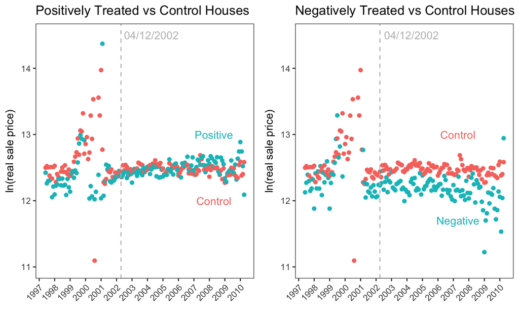

```r
# Visual display of daily lrsp averages over timeframe - positive treatment and control
pos = monthly_lrsp_pos %>%
  ggplot( aes(x = yearmon , y = lrsp , color = as.factor(treat)) ) +
  geom_point() +
  theme_bw() +
  scale_x_date( breaks = scales::pretty_breaks(20) ) +
  scale_y_continuous(limits = c(11,14.5)) +
  annotate(geom = "text" , x = ymd("2008-04-17") , y = 13 , label = "Positive" , col = "#00BFC4") +
  annotate(geom = "text" , x = ymd("2008-04-17") , y = 12 , label = "Control" , col = "#F8766D") +
  theme( axis.text.x = element_text(angle = 45 , hjust = 1) ,
         legend.position = "n" ,
         panel.grid = element_blank() ) +
  labs( x = "" ,
        y = "ln(real sale price)" ,
        color = "" ,
        title = "Positively Treated vs Control Houses") +
  geom_vline(xintercept = ymd("2002-04-01")+14 , col = "gray" , lty = 2) +
  annotate( "text" , x = ymd("2004-04-01") , y = 14.5 , label = "04/12/2002" , col = "gray" )
# Visual display of daily lrsp averages over timeframe - negative treatment and control
neg = monthly_lrsp_neg %>%
  ggplot( aes(x = yearmon , y = lrsp , color = as.factor(treat)) ) +
  geom_point() +
  theme_bw() +
  scale_x_date( breaks = scales::pretty_breaks(20) ) +
  scale_y_continuous(limits = c(11,14.5)) +
  annotate(geom = "text" , x = ymd("2007-04-17") , y = 13 , label = "Control" , col = "#F8766D") +
  annotate(geom = "text" , x = ymd("2007-04-17") , y = 11.7 , label = "Negative" , col = "#00BFC4") +
  theme( axis.text.x = element_text(angle = 45, hjust = 1) ,
         legend.position = "n" ,
         panel.grid = element_blank() ) +
  labs( x = "" ,
        y = "ln(real sale price)" ,
        color = "" ,
        title = "Negatively Treated vs Control Houses") +
  geom_vline(xintercept = ymd("2002-04-01") , col = "gray" , lty = 2) +
  annotate( "text" , x = ymd("2004-04-01")+14 , y = 14.5 , label = "04/12/2002" , col = "gray" )
# Assemble both graphics side-by-side
grid.arrange(pos , neg , ncol = 2)
```

Plot simple month-over-month trend lines and overlay on to plot

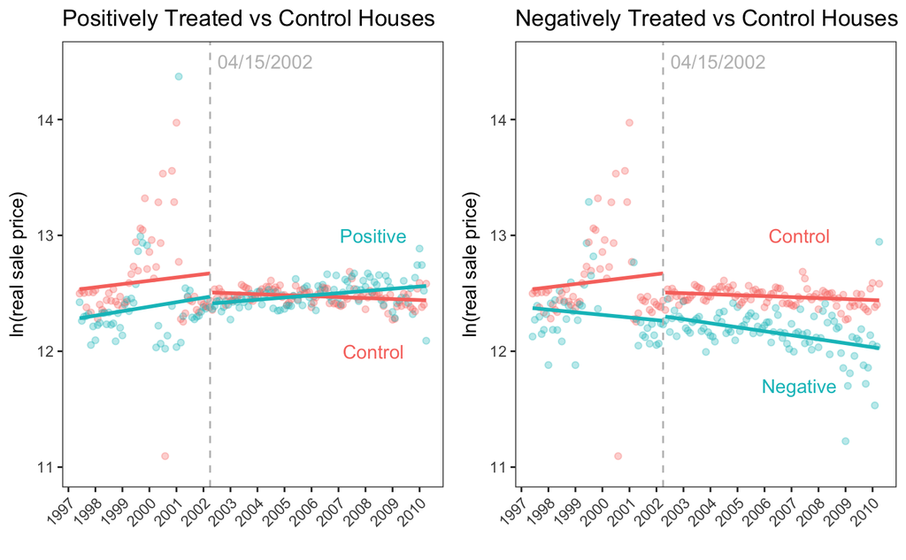

```r
# Visual display of daily lrsp averages over timeframe - positive treatment and control
pos = monthly_lrsp_pos %>%
  ggplot( aes(x = yearmon , y = lrsp , color = factor(treat)) ) +
  geom_point(alpha = 0.3) +
  geom_smooth( data = subset(monthly_lrsp_pos , yearmon < "2002-05-01") ,
               aes( x = yearmon , y = lrsp , color = factor(treat) ) , method = lm , se = FALSE ) +
  geom_smooth( data = subset(monthly_lrsp_pos , yearmon >= "2002-05-01") ,
               aes( x = yearmon , y = lrsp , color = factor(treat) ) , method = lm , se = FALSE ) +
  theme_bw() +
  scale_x_date( breaks = scales::pretty_breaks(20) ) +
  scale_y_continuous(limits = c(11,14.5)) +
  annotate(geom = "text" , x = ymd("2008-04-17") , y = 13 , label = "Positive" , col = "#00BFC4") +
  annotate(geom = "text" , x = ymd("2008-04-17") , y = 12 , label = "Control" , col = "#F8766D") +
  theme( axis.text.x = element_text(angle = 45, hjust = 1) ,
         legend.position = "n" ,
         panel.grid = element_blank() ) +
  labs( x = "" ,
        y = "ln(real sale price)" ,
        color = "" ,
        title = "Positively Treated vs Control Houses") +
  geom_vline(xintercept = ymd("2002-04-01") , col = "gray" , lty = 2) +
  annotate( "text" , x = ymd("2004-04-01")+14 , y = 14.5 , label = "04/15/2002" , col = "gray" )
# Visual display of daily lrsp averages over timeframe - negative treatment and control
neg = monthly_lrsp_neg %>%
  ggplot( aes(x = yearmon , y = lrsp , color = as.factor(treat)) ) +
  geom_point(alpha = 0.3) +
  theme_bw() +
  geom_smooth( data = subset(monthly_lrsp_neg , yearmon < "2002-05-01") ,
               aes( x = yearmon , y = lrsp , color = factor(treat) ) , method = lm , se = FALSE ) +
  geom_smooth( data = subset(monthly_lrsp_neg , yearmon >= "2002-05-01") ,
               aes( x = yearmon , y = lrsp , color = factor(treat) ) , method = lm , se = FALSE ) +
  scale_x_date( breaks = scales::pretty_breaks(20) ) +
  scale_y_continuous(limits = c(11,14.5)) +
  annotate(geom = "text" , x = ymd("2007-04-17") , y = 13 , label = "Control" , col = "#F8766D") +
  annotate(geom = "text" , x = ymd("2007-04-17") , y = 11.7 , label = "Negative" , col = "#00BFC4") +
  theme( axis.text.x = element_text(angle = 45, hjust = 1) ,
         legend.position = "n" ,
         panel.grid = element_blank() ) +
  labs( x = "" ,
        y = "ln(real sale price)" ,
        color = "" ,
        title = "Negatively Treated vs Control Houses") +
  geom_vline(xintercept = ymd("2002-04-01") , col = "gray" , lty = 2) +
  annotate( "text" , x = ymd("2004-04-01")+14 , y = 14.5 , label = "04/15/2002" , col = "gray" )
# Assemble both graphics side-by-side
grid.arrange(pos , neg , ncol = 2)
```

Notes:

- Data issues from MLS in late 1999 to early 2001 obfuscate empirical trend lines and house prices (average monthly house prices during this period calculated from small numbers of house sales, sometimes 1, 2, 3. Some months have no house sales). Had this data not been lost, would have seen sharper patterns and likely closer trend lines without such a disparate drop down. Story here is in the slopes, not the immediate effects! (Lottery offset these)
- Trends essentially parallel in positive/control pre-busing period; clear change in trends afterward, with positive control group of neighborhood-houses continuing upward trajectory, while control switch tack. Also, large drop-down relative to positively treated neighborhoods indicates bigger negative effect at first and then substantial on-going effects from change in school assignment policy. People bidding up house prices in these areas relative to control houses (which are fall in house price post-busing).
- Negative trends tell another side of the story: no immediate effects for negatiely treated houses relative to controls; negative slope didn’t change much either. Control slope, as before, is (would be less) slightly positive until busing decision, then gradually negative afterward. Negative prices bid down slightly faster in post-busing era.

# Regression analyses

## Linear DiD models

Linear models encapsulate both dummy-treatment and EOC-difference treatment.

```r
# Treatments are categorical here (0,1 and interactions) and for date sold before/after rezoning
treated_df = full_clt %>%
  mutate( year_fe = factor(year(daily)) ) %>%
  # First are neighborhood treatments
  mutate( rezone = ifelse(treat == 1 | treat == 2 , 1 , 0) ) %>%
  # Next are date treatments
  mutate( post2002 = ifelse(sold < "2002-04-15", 0 , 1) ) %>%
  # Interaction of two is treatment, positive treatment, and negative treatment
  mutate( treat = rezone*post2002 )
# Positively treated dataframe
treated_pos_df = full_clt %>%
  filter( treat %in% c(0,1) ) %>%
  mutate( year_fe = factor(year(daily)) ) %>%
  # First are neighborhood treatments
  mutate( rezonepos = ifelse(treat == 1 , 1 , 0) ) %>%
  # Next are date treatments
  mutate( post2002 = ifelse(sold < "2002-04-15", 0 , 1) ) %>%
  # Interaction of two is treatment, positive treatment, and negative treatment
  mutate( treatpos = rezonepos*post2002 ,
          eocptreat = eocdifference*treatpos)
# Positively treated dataframe
treated_neg_df = full_clt %>%
  filter( treat %in% c(0,2) ) %>%
  mutate( year_fe = factor(year(daily)) ) %>%
  # First are neighborhood treatments
  mutate( rezoneneg = ifelse(treat == 2 , 1 , 0) ) %>%
  # Next are date treatments
  mutate( post2002 = ifelse(sold < "2002-04-15", 0 , 1) ) %>%
  # Interaction of two is treatment, positive treatment, and negative treatment
  mutate( treatneg = rezoneneg*post2002 ,
          eocntreat = eocdifference*treatneg)
```

Simple first-pass regressions without hedonic covariates

```r
# Full treatment (aggregating both positive and negative treatment effects)
simp_reg = lm( lrsp ~ rezone + post2002 + treat , data = treated_df)
summary(simp_reg)
```

```
Call:
lm(formula = lrsp ~ rezone + post2002 + treat, data = treated_df)

Residuals:
    Min      1Q  Median      3Q     Max
-3.1914 -0.4232 -0.0918  0.3513  3.3100

Coefficients:
             Estimate Std. Error  t value Pr(>|t|)
(Intercept) 12.435379   0.008500 1462.994  < 2e-16 ***
rezone      -0.133615   0.015329   -8.716  < 2e-16 ***
post2002     0.053402   0.009354    5.709 1.14e-08 ***
treat        0.044271   0.016696    2.652  0.00802 **
---
Signif. codes:  0 ‘***’ 0.001 ‘**’ 0.01 ‘*’ 0.05 ‘.’ 0.1 ‘ ’ 1

Residual standard error: 0.5998 on 43390 degrees of freedom
Multiple R-squared:  0.00744,   Adjusted R-squared:  0.007371
F-statistic: 108.4 on 3 and 43390 DF,  p-value: < 2.2e-16
```

```r
# Overall treatment
summary( lm_robust(lrsp ~ rezone + post2002 + treat ,
                data = treated_df ,
                se_type = "stata" ,
                clusters = treated_df$subdiv) )
```

```
Call:
lm_robust(formula = lrsp ~ rezone + post2002 + treat, data = treated_df,
    clusters = treated_df$subdiv, se_type = "stata")

Standard error type:  stata

Coefficients:
            Estimate Std. Error  t value Pr(>|t|) CI Lower CI Upper  DF
(Intercept) 12.43538    0.05464 227.5681   0.0000 12.32812 12.54264 819
rezone      -0.13362    0.08157  -1.6381   0.1018 -0.29372  0.02649 819
post2002     0.05340    0.04835   1.1044   0.2697 -0.04151  0.14831 819
treat        0.04427    0.07759   0.5706   0.5684 -0.10802  0.19656 819

Multiple R-squared:  0.00744 ,  Adjusted R-squared:  0.007371
F-statistic: 7.028 on 3 and 819 DF,  p-value: 0.0001142
```

```r
# Positively treated
summary( lm_robust(lrsp ~ rezonepos + post2002 + treatpos ,
                data = treated_pos_df ,
                se_type = "stata" ,
                clusters = treated_pos_df$subdiv) )
```

```
Call:
lm_robust(formula = lrsp ~ rezonepos + post2002 + treatpos, data = treated_pos_df,
    clusters = treated_pos_df$subdiv, se_type = "stata")

Standard error type:  stata

Coefficients:
            Estimate Std. Error  t value Pr(>|t|) CI Lower CI Upper  DF
(Intercept) 12.43538    0.05465 227.5448   0.0000 12.32808  12.5427 705
rezonepos   -0.09079    0.09784  -0.9280   0.3537 -0.28288   0.1013 705
post2002     0.05340    0.04836   1.1043   0.2698 -0.04154   0.1483 705
treatpos     0.08827    0.09099   0.9701   0.3323 -0.09037   0.2669 705

Multiple R-squared:  0.002752 , Adjusted R-squared:  0.002675
F-statistic: 6.101 on 3 and 705 DF,  p-value: 0.0004228
```

```r
# Negatively treated
summary( lm_robust(lrsp ~ rezoneneg + post2002 + treatneg ,
                data = treated_neg_df ,
                se_type = "stata" ,
                clusters = treated_neg_df$subdiv) )
```

```
Call:
lm_robust(formula = lrsp ~ rezoneneg + post2002 + treatneg, data = treated_neg_df,
    clusters = treated_neg_df$subdiv, se_type = "stata")

Standard error type:  stata

Coefficients:
            Estimate Std. Error  t value Pr(>|t|) CI Lower CI Upper  DF
(Intercept) 12.43538    0.05465 227.5364 0.000000 12.32807 12.54269 676
rezoneneg   -0.22471    0.08052  -2.7909 0.005404 -0.38280 -0.06662 676
post2002     0.05340    0.04836   1.1043 0.269877 -0.04155  0.14836 676
treatneg    -0.06421    0.06950  -0.9238 0.355926 -0.20068  0.07226 676

Multiple R-squared:  0.02699 ,  Adjusted R-squared:  0.0269
F-statistic: 5.547 on 3 and 676 DF,  p-value: 0.0009159
```

Incorporate hedonic variables into the analyses

```r
# Overall treatment
summary( lm_robust(
  lrsp ~ rezone + post2002 + treat + acres + beds + baths + half_baths + new + age + agesq + year_fe ,
                data = treated_df ,
                se_type = "stata" ,
                clusters = treated_df$subdiv) )
```

```
Call:
lm_robust(formula = lrsp ~ rezone + post2002 + treat + acres +
    beds + baths + half_baths + new + age + agesq + year_fe,
    data = treated_df, clusters = treated_df$subdiv, se_type = "stata")

Standard error type:  stata

Coefficients:
              Estimate Std. Error t value  Pr(>|t|)   CI Lower  CI Upper  DF
(Intercept) 10.3413370  1.056e-01 97.8996 0.000e+00 10.1339956 10.548678 819
rezone      -0.0422238  3.584e-02 -1.1782 2.391e-01 -0.1125680  0.028121 819
post2002     0.0090313  1.491e-02  0.6056 5.449e-01 -0.0202390  0.038302 819
treat        0.0163842  3.300e-02  0.4964 6.197e-01 -0.0483986  0.081167 819
acres        0.2577913  3.458e-02  7.4556 2.279e-13  0.1899217  0.325661 819
beds         0.2282651  1.198e-02 19.0498 2.944e-67  0.2047450  0.251785 819
baths        0.4105224  2.492e-02 16.4759 6.839e-53  0.3616145  0.459430 819
half_baths   0.3252578  2.726e-02 11.9313 2.267e-30  0.2717486  0.378767 819
new          0.0233255  2.821e-02  0.8270 4.085e-01 -0.0320385  0.078689 819
age         -0.0107490  2.677e-03 -4.0155 6.477e-05 -0.0160033 -0.005495 819
agesq        0.0002412  2.999e-05  8.0400 3.135e-15  0.0001823  0.000300 819
year_fe1998 -0.0137953  2.249e-02 -0.6134 5.398e-01 -0.0579372  0.030347 819
year_fe1999  0.0254708  2.802e-02  0.9089 3.637e-01 -0.0295378  0.080479 819
year_fe2000  0.0753466  6.661e-02  1.1312 2.583e-01 -0.0553938  0.206087 819
year_fe2001 -0.0361645  3.622e-02 -0.9986 3.183e-01 -0.1072500  0.034921 819
year_fe2002 -0.0451954  3.837e-02 -1.1779 2.392e-01 -0.1205125  0.030122 819
year_fe2003 -0.0389490  3.877e-02 -1.0045 3.154e-01 -0.1150585  0.037161 819
year_fe2004 -0.0340333  3.822e-02 -0.8905 3.734e-01 -0.1090491  0.040982 819
year_fe2005 -0.0419141  3.946e-02 -1.0623 2.884e-01 -0.1193633  0.035535 819
year_fe2006 -0.0205528  4.102e-02 -0.5010 6.165e-01 -0.1010732  0.059968 819
year_fe2007  0.0067919  4.183e-02  0.1624 8.711e-01 -0.0753218  0.088906 819
year_fe2008 -0.0342232  4.449e-02 -0.7692 4.420e-01 -0.1215512  0.053105 819
year_fe2009 -0.1283829  4.324e-02 -2.9689 3.076e-03 -0.2132616 -0.043504 819
year_fe2010 -0.1644534  4.861e-02 -3.3828 7.515e-04 -0.2598767 -0.069030 819

Multiple R-squared:  0.5902 ,   Adjusted R-squared:  0.5899
F-statistic: 116.5 on 23 and 819 DF,  p-value: < 2.2e-16
```

```r
# Treatment-by-year
summary( lm_robust(
  lrsp ~ rezone + acres + beds + baths + half_baths + new + age + agesq + year_fe + year_fe*rezone ,
                data = treated_df ,
                se_type = "stata" ,
                clusters = treated_df$subdiv) )
```

```
Call:
lm_robust(formula = lrsp ~ rezone + acres + beds + baths + half_baths +
    new + age + agesq + year_fe + year_fe * rezone, data = treated_df,
    clusters = treated_df$subdiv, se_type = "stata")

Standard error type:  stata

Coefficients:
                     Estimate Std. Error  t value  Pr(>|t|)   CI Lower   CI Upper  DF
(Intercept)        10.3492415  1.062e-01 97.46570 0.000e+00 10.1408178 10.5576652 819
rezone             -0.0640722  6.448e-02 -0.99362 3.207e-01 -0.1906449  0.0625005 819
acres               0.2579639  3.457e-02  7.46100 2.193e-13  0.1900979  0.3258299 819
beds                0.2283475  1.195e-02 19.10282 1.459e-67  0.2048842  0.2518109 819
baths               0.4103150  2.474e-02 16.58572 1.744e-53  0.3617556  0.4588744 819
half_baths          0.3255885  2.731e-02 11.91997 2.547e-30  0.2719737  0.3792033 819
new                 0.0230908  2.803e-02  0.82367 4.104e-01 -0.0319359  0.0781175 819
age                -0.0107564  2.674e-03 -4.02274 6.285e-05 -0.0160050 -0.0055079 819
agesq               0.0002412  2.998e-05  8.04567 3.004e-15  0.0001824  0.0003001 819
year_fe1998        -0.0175211  2.540e-02 -0.68985 4.905e-01 -0.0673745  0.0323324 819
year_fe1999         0.0194572  3.570e-02  0.54498 5.859e-01 -0.0506228  0.0895373 819
year_fe2000         0.1336878  7.142e-02  1.87172 6.160e-02 -0.0065097  0.2738854 819
year_fe2001        -0.0461061  4.778e-02 -0.96499 3.348e-01 -0.1398896  0.0476774 819
year_fe2002        -0.0490479  4.884e-02 -1.00416 3.156e-01 -0.1449233  0.0468275 819
year_fe2003        -0.0374475  5.020e-02 -0.74599 4.559e-01 -0.1359800  0.0610849 819
year_fe2004        -0.0294669  4.937e-02 -0.59687 5.508e-01 -0.1263718  0.0674381 819
year_fe2005        -0.0420757  5.015e-02 -0.83900 4.017e-01 -0.1405124  0.0563611 819
year_fe2006        -0.0229368  5.006e-02 -0.45815 6.470e-01 -0.1212053  0.0753316 819
year_fe2007         0.0102889  5.128e-02  0.20063 8.410e-01 -0.0903713  0.1109491 819
year_fe2008        -0.0448541  5.198e-02 -0.86296 3.884e-01 -0.1468783  0.0571701 819
year_fe2009        -0.1131850  5.271e-02 -2.14722 3.207e-02 -0.2166523 -0.0097178 819
year_fe2010        -0.1560135  5.937e-02 -2.62780 8.755e-03 -0.2725496 -0.0394774 819
rezone:year_fe1998  0.0068543  4.663e-02  0.14699 8.832e-01 -0.0846764  0.0983849 819
rezone:year_fe1999  0.0149455  5.895e-02  0.25352 7.999e-01 -0.1007699  0.1306610 819
rezone:year_fe2000 -0.1913143  8.504e-02 -2.24976 2.473e-02 -0.3582317 -0.0243969 819
rezone:year_fe2001  0.0286025  6.844e-02  0.41790 6.761e-01 -0.1057423  0.1629473 819
rezone:year_fe2002  0.0415700  7.403e-02  0.56155 5.746e-01 -0.1037360  0.1868760 819
rezone:year_fe2003  0.0369924  7.214e-02  0.51276 6.083e-01 -0.1046163  0.1786011 819
rezone:year_fe2004  0.0282293  7.221e-02  0.39094 6.959e-01 -0.1135053  0.1699639 819
rezone:year_fe2005  0.0416175  7.303e-02  0.56990 5.689e-01 -0.1017215  0.1849565 819
rezone:year_fe2006  0.0479931  7.882e-02  0.60890 5.428e-01 -0.1067193  0.2027054 819
rezone:year_fe2007  0.0314052  7.919e-02  0.39658 6.918e-01 -0.1240324  0.1868427 819
rezone:year_fe2008  0.0731680  8.913e-02  0.82087 4.120e-01 -0.1017915  0.2481274 819
rezone:year_fe2009 -0.0064405  8.549e-02 -0.07534 9.400e-01 -0.1742404  0.1613595 819
rezone:year_fe2010  0.0165725  1.019e-01  0.16265 8.708e-01 -0.1834229  0.2165679 819

Multiple R-squared:  0.5903 ,   Adjusted R-squared:   0.59
F-statistic: 99.88 on 34 and 819 DF,  p-value: < 2.2e-16
```

Positive treatment regression results by total and year-over-year

```r
# Positively treated
summary(lm_robust(
  lrsp ~ rezonepos + post2002 + treatpos + acres + beds + baths + half_baths + new + age + agesq + year_fe ,
                data = treated_pos_df ,
                se_type = "stata" ,
                clusters = treated_pos_df$subdiv) )
```

```
Call:
lm_robust(formula = lrsp ~ rezonepos + post2002 + treatpos +
    acres + beds + baths + half_baths + new + age + agesq + year_fe,
    data = treated_pos_df, clusters = treated_pos_df$subdiv,
    se_type = "stata")

Standard error type:  stata

Coefficients:
              Estimate Std. Error t value  Pr(>|t|)   CI Lower   CI Upper  DF
(Intercept) 10.2782186  1.031e-01 99.7126 0.000e+00 10.0758411 10.4805962 705
rezonepos   -0.0279918  4.384e-02 -0.6385 5.234e-01 -0.1140685  0.0580849 705
post2002     0.0026083  1.487e-02  0.1754 8.608e-01 -0.0265800  0.0317966 705
treatpos     0.0419571  3.881e-02  1.0811 2.800e-01 -0.0342389  0.1181532 705
acres        0.2517018  3.676e-02  6.8473 1.639e-11  0.1795314  0.3238722 705
beds         0.2304178  1.311e-02 17.5809 1.200e-57  0.2046861  0.2561494 705
baths        0.4106394  2.439e-02 16.8344 1.049e-53  0.3627481  0.4585306 705
half_baths   0.3332363  2.684e-02 12.4173 3.700e-32  0.2805474  0.3859252 705
new          0.0327836  2.908e-02  1.1272 2.600e-01 -0.0243191  0.0898864 705
age         -0.0074918  2.841e-03 -2.6370 8.547e-03 -0.0130696 -0.0019140 705
agesq        0.0002093  3.006e-05  6.9611 7.736e-12  0.0001503  0.0002683 705
year_fe1998 -0.0222214  2.388e-02 -0.9304 3.525e-01 -0.0691119  0.0246692 705
year_fe1999  0.0264599  3.037e-02  0.8711 3.840e-01 -0.0331743  0.0860942 705
year_fe2000  0.0755925  6.774e-02  1.1160 2.648e-01 -0.0574001  0.2085851 705
year_fe2001 -0.0348558  3.994e-02 -0.8727 3.831e-01 -0.1132676  0.0435560 705
year_fe2002 -0.0441561  4.205e-02 -1.0502 2.940e-01 -0.1267069  0.0383948 705
year_fe2003 -0.0350589  4.262e-02 -0.8226 4.110e-01 -0.1187352  0.0486174 705
year_fe2004 -0.0282122  4.198e-02 -0.6720 5.018e-01 -0.1106354  0.0542110 705
year_fe2005 -0.0361428  4.328e-02 -0.8351 4.039e-01 -0.1211158  0.0488302 705
year_fe2006 -0.0127027  4.441e-02 -0.2860 7.749e-01 -0.0998986  0.0744932 705
year_fe2007  0.0174319  4.502e-02  0.3872 6.987e-01 -0.0709642  0.1058280 705
year_fe2008 -0.0279192  4.753e-02 -0.5874 5.571e-01 -0.1212388  0.0654005 705
year_fe2009 -0.1096260  4.583e-02 -2.3919 1.702e-02 -0.1996104 -0.0196416 705
year_fe2010 -0.1489933  5.075e-02 -2.9360 3.433e-03 -0.2486270 -0.0493596 705

Multiple R-squared:  0.5992 ,   Adjusted R-squared:  0.5989
F-statistic: 118.7 on 23 and 705 DF,  p-value: < 2.2e-16
```

```r
# Year-over-year
summary(lm_robust(
  lrsp ~ rezonepos + acres + beds + baths + half_baths + new + age + agesq + year_fe + year_fe*rezonepos ,
                data = treated_pos_df ,
                se_type = "stata" ,
                clusters = treated_pos_df$subdiv) )
```

```
Call:
lm_robust(formula = lrsp ~ rezonepos + acres + beds + baths +
    half_baths + new + age + agesq + year_fe + year_fe * rezonepos,
    data = treated_pos_df, clusters = treated_pos_df$subdiv,
    se_type = "stata")

Standard error type:  stata

Coefficients:
                        Estimate Std. Error  t value  Pr(>|t|)   CI Lower   CI Upper  DF
(Intercept)           10.2860771  1.024e-01 100.4107 0.000e+00 10.0849529 10.4872013 705
rezonepos             -0.0522850  7.186e-02  -0.7276 4.671e-01 -0.1933639  0.0887939 705
acres                  0.2520432  3.675e-02   6.8576 1.532e-11  0.1798833  0.3242030 705
beds                   0.2305522  1.311e-02  17.5809 1.200e-57  0.2048055  0.2562989 705
baths                  0.4099976  2.415e-02  16.9755 1.910e-54  0.3625786  0.4574166 705
half_baths             0.3333058  2.686e-02  12.4097 4.002e-32  0.2805734  0.3860382 705
new                    0.0325853  2.878e-02   1.1322 2.579e-01 -0.0239191  0.0890897 705
age                   -0.0074996  2.841e-03  -2.6395 8.487e-03 -0.0130780 -0.0019212 705
agesq                  0.0002093  3.004e-05   6.9669 7.443e-12  0.0001503  0.0002683 705
year_fe1998           -0.0165949  2.560e-02  -0.6483 5.170e-01 -0.0668520  0.0336622 705
year_fe1999            0.0213406  3.586e-02   0.5952 5.519e-01 -0.0490590  0.0917403 705
year_fe2000            0.1378216  7.233e-02   1.9054 5.713e-02 -0.0041883  0.2798314 705
year_fe2001           -0.0457656  4.809e-02  -0.9516 3.416e-01 -0.1401891  0.0486580 705
year_fe2002           -0.0481234  4.920e-02  -0.9780 3.284e-01 -0.1447278  0.0484811 705
year_fe2003           -0.0363463  5.055e-02  -0.7190 4.723e-01 -0.1355887  0.0628961 705
year_fe2004           -0.0276311  4.973e-02  -0.5557 5.786e-01 -0.1252582  0.0699960 705
year_fe2005           -0.0397488  5.045e-02  -0.7879 4.310e-01 -0.1388027  0.0593052 705
year_fe2006           -0.0212176  5.042e-02  -0.4208 6.740e-01 -0.1202022  0.0777670 705
year_fe2007            0.0117123  5.157e-02   0.2271 8.204e-01 -0.0895426  0.1129671 705
year_fe2008           -0.0432642  5.219e-02  -0.8290 4.074e-01 -0.1457336  0.0592052 705
year_fe2009           -0.1130241  5.292e-02  -2.1356 3.305e-02 -0.2169298 -0.0091184 705
year_fe2010           -0.1547221  5.931e-02  -2.6087 9.281e-03 -0.2711667 -0.0382776 705
rezonepos:year_fe1998 -0.0337019  5.378e-02  -0.6267 5.311e-01 -0.1392879  0.0718841 705
rezonepos:year_fe1999  0.0161592  6.949e-02   0.2325 8.162e-01 -0.1202773  0.1525956 705
rezonepos:year_fe2000 -0.1975632  9.025e-02  -2.1890 2.892e-02 -0.3747583 -0.0203681 705
rezonepos:year_fe2001  0.0432035  8.131e-02   0.5313 5.954e-01 -0.1164442  0.2028513 705
rezonepos:year_fe2002  0.0521115  8.854e-02   0.5886 5.563e-01 -0.1217153  0.2259382 705
rezonepos:year_fe2003  0.0550327  8.588e-02   0.6408 5.218e-01 -0.1135740  0.2236395 705
rezonepos:year_fe2004  0.0478255  8.699e-02   0.5498 5.826e-01 -0.1229677  0.2186188 705
rezonepos:year_fe2005  0.0638248  8.864e-02   0.7200 4.717e-01 -0.1102075  0.2378571 705
rezonepos:year_fe2006  0.0812247  9.353e-02   0.8684 3.854e-01 -0.1024052  0.2648546 705
rezonepos:year_fe2007  0.0712051  9.203e-02   0.7737 4.394e-01 -0.1094816  0.2518918 705
rezonepos:year_fe2008  0.1079975  1.050e-01   1.0282 3.042e-01 -0.0982191  0.3142140 705
rezonepos:year_fe2009  0.0627873  9.332e-02   0.6728 5.013e-01 -0.1204300  0.2460046 705
rezonepos:year_fe2010  0.0720392  1.102e-01   0.6540 5.134e-01 -0.1442403  0.2883188 705

Multiple R-squared:  0.5994 ,   Adjusted R-squared:  0.599
F-statistic: 111.6 on 34 and 705 DF,  p-value: < 2.2e-16
```

Negative treatment regression results by total and year-over-year

```r
# Negatively treated
summary( lm_robust(
  lrsp ~ rezoneneg + post2002 + treatneg + acres + beds + baths + half_baths + new + age + agesq + year_fe ,
                data = treated_neg_df ,
                se_type = "stata" ,
                clusters = treated_neg_df$subdiv) )
```

```
Call:
lm_robust(formula = lrsp ~ rezoneneg + post2002 + treatneg +
    acres + beds + baths + half_baths + new + age + agesq + year_fe,
    data = treated_neg_df, clusters = treated_neg_df$subdiv,
    se_type = "stata")

Standard error type:  stata

Coefficients:
              Estimate Std. Error   t value  Pr(>|t|)   CI Lower   CI Upper  DF
(Intercept) 10.4807095  9.646e-02 108.65309 0.000e+00 10.2913116 10.6701073 676
rezoneneg   -0.0590893  3.991e-02  -1.48042 1.392e-01 -0.1374595  0.0192809 676
post2002     0.0192129  1.366e-02   1.40668 1.600e-01 -0.0076049  0.0460306 676
treatneg    -0.0344496  3.721e-02  -0.92594 3.548e-01 -0.1075014  0.0386021 676
acres        0.3094283  4.021e-02   7.69518 5.018e-14  0.2304755  0.3883811 676
beds         0.2309781  1.546e-02  14.93808 8.220e-44  0.2006181  0.2613382 676
baths        0.3832569  2.174e-02  17.62842 1.639e-57  0.3405692  0.4259446 676
half_baths   0.2800426  2.446e-02  11.44695 7.432e-28  0.2320073  0.3280779 676
new         -0.0003788  3.077e-02  -0.01231 9.902e-01 -0.0608036  0.0600460 676
age         -0.0127633  2.672e-03  -4.77645 2.189e-06 -0.0180100 -0.0075166 676
agesq        0.0002180  3.684e-05   5.91785 5.185e-09  0.0001457  0.0002903 676
year_fe1998 -0.0069169  2.390e-02  -0.28940 7.724e-01 -0.0538463  0.0400125 676
year_fe1999  0.0260412  3.172e-02   0.82085 4.120e-01 -0.0362499  0.0883322 676
year_fe2000  0.1574376  6.655e-02   2.36575 1.827e-02  0.0267706  0.2881046 676
year_fe2001 -0.0365791  4.303e-02  -0.85006 3.956e-01 -0.1210704  0.0479122 676
year_fe2002 -0.0484064  4.498e-02  -1.07606 2.823e-01 -0.1367333  0.0399205 676
year_fe2003 -0.0421513  4.703e-02  -0.89618 3.705e-01 -0.1345025  0.0501999 676
year_fe2004 -0.0349949  4.603e-02  -0.76028 4.474e-01 -0.1253716  0.0553817 676
year_fe2005 -0.0489392  4.680e-02  -1.04573 2.961e-01 -0.1408282  0.0429498 676
year_fe2006 -0.0337699  4.683e-02  -0.72113 4.711e-01 -0.1257187  0.0581788 676
year_fe2007 -0.0040110  4.804e-02  -0.08349 9.335e-01 -0.0983356  0.0903135 676
year_fe2008 -0.0516631  4.888e-02  -1.05700 2.909e-01 -0.1476323  0.0443060 676
year_fe2009 -0.1343923  4.973e-02  -2.70259 7.053e-03 -0.2320308 -0.0367538 676
year_fe2010 -0.1741071  5.656e-02  -3.07814 2.167e-03 -0.2851662 -0.0630481 676

Multiple R-squared:  0.5936 ,   Adjusted R-squared:  0.5933
F-statistic: 106.5 on 23 and 676 DF,  p-value: < 2.2e-16
```

```r
# Year-over-year
summary( lm_robust(
  lrsp ~ rezoneneg + acres + beds + baths + half_baths + new + age + agesq + year_fe + rezoneneg*year_fe ,
                data = treated_neg_df ,
                se_type = "stata" ,
                clusters = treated_neg_df$subdiv) )
```

```
1 coefficient  not defined because the design matrix is rank deficient
```

```
Call:
lm_robust(formula = lrsp ~ rezoneneg + acres + beds + baths +
    half_baths + new + age + agesq + year_fe + rezoneneg * year_fe,
    data = treated_neg_df, clusters = treated_neg_df$subdiv,
    se_type = "stata")

Standard error type:  stata

Coefficients: (1 not defined because the design matrix is rank deficient)
                        Estimate Std. Error   t value  Pr(>|t|)   CI Lower   CI Upper  DF
(Intercept)           10.4857028  9.866e-02 106.28360 0.000e+00 10.2919903 10.6794153 676
rezoneneg             -0.0962250  7.653e-02  -1.25736 2.091e-01 -0.2464884  0.0540384 676
acres                  0.3092009  4.013e-02   7.70470 4.686e-14  0.2304036  0.3879983 676
beds                   0.2303399  1.543e-02  14.92394 9.640e-44  0.2000351  0.2606447 676
baths                  0.3837851  2.176e-02  17.64001 1.424e-57  0.3410667  0.4265036 676
half_baths             0.2798160  2.439e-02  11.47417 5.713e-28  0.2319334  0.3276986 676
new                    0.0009271  3.105e-02   0.02986 9.762e-01 -0.0600353  0.0618895 676
age                   -0.0126752  2.676e-03  -4.73608 2.656e-06 -0.0179301 -0.0074203 676
agesq                  0.0002174  3.672e-05   5.92054 5.105e-09  0.0001453  0.0002895 676
year_fe1998           -0.0191615  2.545e-02  -0.75287 4.518e-01 -0.0691346  0.0308117 676
year_fe1999            0.0211924  3.509e-02   0.60396 5.461e-01 -0.0477048  0.0900896 676
year_fe2000            0.1516473  6.668e-02   2.27415 2.327e-02  0.0207162  0.2825783 676
year_fe2001           -0.0410919  4.879e-02  -0.84216 4.000e-01 -0.1368963  0.0547125 676
year_fe2002           -0.0434572  4.958e-02  -0.87653 3.811e-01 -0.1408039  0.0538896 676
year_fe2003           -0.0307034  5.083e-02  -0.60409 5.460e-01 -0.1304991  0.0690923 676
year_fe2004           -0.0227200  4.997e-02  -0.45468 6.495e-01 -0.1208332  0.0753933 676
year_fe2005           -0.0377554  5.077e-02  -0.74367 4.573e-01 -0.1374391  0.0619283 676
year_fe2006           -0.0183607  5.068e-02  -0.36230 7.172e-01 -0.1178665  0.0811451 676
year_fe2007            0.0150810  5.170e-02   0.29169 7.706e-01 -0.0864364  0.1165985 676
year_fe2008           -0.0394965  5.278e-02  -0.74837 4.545e-01 -0.1431231  0.0641301 676
year_fe2009           -0.1045769  5.293e-02  -1.97591 4.857e-02 -0.2084958 -0.0006580 676
year_fe2010           -0.1469328  6.049e-02  -2.42908 1.540e-02 -0.2657016 -0.0281639 676
rezoneneg:year_fe1998  0.1028881  5.475e-02   1.87931 6.063e-02 -0.0046083  0.2103845 676
rezoneneg:year_fe1999  0.0309888  7.473e-02   0.41467 6.785e-01 -0.1157448  0.1777224 676
rezoneneg:year_fe2000         NA         NA        NA        NA         NA         NA  NA
rezoneneg:year_fe2001  0.0304242  7.986e-02   0.38099 7.033e-01 -0.1263709  0.1872193 676
rezoneneg:year_fe2002  0.0423718  7.997e-02   0.52988 5.964e-01 -0.1146382  0.1993818 676
rezoneneg:year_fe2003  0.0201382  7.998e-02   0.25180 8.013e-01 -0.1368968  0.1771733 676
rezoneneg:year_fe2004  0.0137940  8.241e-02   0.16739 8.671e-01 -0.1480108  0.1755988 676
rezoneneg:year_fe2005  0.0212172  8.173e-02   0.25961 7.952e-01 -0.1392493  0.1816836 676
rezoneneg:year_fe2006 -0.0080334  9.799e-02  -0.08198 9.347e-01 -0.2004405  0.1843738 676
rezoneneg:year_fe2007 -0.0359108  1.102e-01  -0.32589 7.446e-01 -0.2522703  0.1804487 676
rezoneneg:year_fe2008  0.0179384  1.184e-01   0.15156 8.796e-01 -0.2144547  0.2503315 676
rezoneneg:year_fe2009 -0.1290076  1.284e-01  -1.00483 3.153e-01 -0.3810937  0.1230785 676
rezoneneg:year_fe2010 -0.0928185  1.416e-01  -0.65566 5.123e-01 -0.3707795  0.1851426 676

Multiple R-squared:  0.5941 ,   Adjusted R-squared:  0.5937
F-statistic:    NA on 33 and 676 DF,  p-value: NA
```

Incorporate EOC-difference (or “doseage”) model for houses in neighborhoods that experienced positive and negative treatment effects of a school reassignment: base models

```r
# Positively treated base model
summary( lm_robust(lrsp ~ eocdifference + post2002 + eocptreat,
                data = treated_pos_df ,
                se_type = "stata" ,
                clusters = treated_pos_df$subdiv) )
```

```
Call:
lm_robust(formula = lrsp ~ eocdifference + post2002 + eocptreat,
    data = treated_pos_df, clusters = treated_pos_df$subdiv,
    se_type = "stata")

Standard error type:  stata

Coefficients:
               Estimate Std. Error  t value Pr(>|t|)  CI Lower CI Upper  DF
(Intercept)   12.407793   0.051568 240.6081 0.000000 12.306547 12.50904 704
eocdifference  0.001832   0.006147   0.2980 0.765797 -0.010237  0.01390 704
post2002       0.029231   0.045686   0.6398 0.522495 -0.060466  0.11893 704
eocptreat      0.008986   0.003131   2.8697 0.004232  0.002838  0.01513 704

Multiple R-squared:  0.02867 ,  Adjusted R-squared:  0.0286
F-statistic: 10.57 on 3 and 704 DF,  p-value: 8.39e-07
```

```r
# Year-over-year base model
summary( lm_robust(lrsp ~ eocdifference + year_fe + eocdifference*year_fe,
                data = treated_pos_df ,
                se_type = "stata" ,
                clusters = treated_pos_df$subdiv) )
```

```
Call:
lm_robust(formula = lrsp ~ eocdifference + year_fe + eocdifference *
    year_fe, data = treated_pos_df, clusters = treated_pos_df$subdiv,
    se_type = "stata")

Standard error type:  stata

Coefficients:
                           Estimate Std. Error   t value  Pr(>|t|)   CI Lower  CI Upper  DF
(Intercept)               12.443416   0.100084 124.33012 0.0000000  1.225e+01 12.639914 704
eocdifference             -0.008168   0.006310  -1.29445 0.1959353 -2.056e-02  0.004221 704
year_fe1998               -0.032706   0.046671  -0.70078 0.4836716 -1.243e-01  0.058925 704
year_fe1999                0.103123   0.056585   1.82247 0.0688082 -7.971e-03  0.214218 704
year_fe2000                0.426809   0.173510   2.45985 0.0141387  8.615e-02  0.767469 704
year_fe2001               -0.056977   0.095466  -0.59683 0.5508117 -2.444e-01  0.130455 704
year_fe2002               -0.034330   0.099222  -0.34599 0.7294516 -2.291e-01  0.160476 704
year_fe2003                0.008475   0.100849   0.08403 0.9330528 -1.895e-01  0.206476 704
year_fe2004                0.044207   0.101692   0.43472 0.6639021 -1.554e-01  0.243864 704
year_fe2005               -0.007805   0.101542  -0.07687 0.9387507 -2.072e-01  0.191556 704
year_fe2006               -0.017547   0.100127  -0.17525 0.8609365 -2.141e-01  0.179036 704
year_fe2007               -0.003723   0.103072  -0.03612 0.9711936 -2.061e-01  0.198643 704
year_fe2008               -0.031823   0.104243  -0.30527 0.7602496 -2.365e-01  0.172842 704
year_fe2009               -0.081066   0.103018  -0.78691 0.4315987 -2.833e-01  0.121193 704
year_fe2010               -0.049273   0.116293  -0.42370 0.6719137 -2.776e-01  0.179049 704
eocdifference:year_fe1998  0.003464   0.003615   0.95818 0.3383006 -3.634e-03  0.010561 704
eocdifference:year_fe1999  0.008536   0.004589   1.85998 0.0633047 -4.743e-04  0.017547 704
eocdifference:year_fe2000 -0.063904   0.035766  -1.78671 0.0744141 -1.341e-01  0.006317 704
eocdifference:year_fe2001  0.011678   0.006161   1.89535 0.0584554 -4.189e-04  0.023775 704
eocdifference:year_fe2002  0.013625   0.007463   1.82577 0.0683087 -1.027e-03  0.028278 704
eocdifference:year_fe2003  0.013974   0.007123   1.96170 0.0501917 -1.171e-05  0.027959 704
eocdifference:year_fe2004  0.015485   0.007346   2.10809 0.0353756  1.063e-03  0.029907 704
eocdifference:year_fe2005  0.018714   0.007517   2.48953 0.0130211  3.955e-03  0.033473 704
eocdifference:year_fe2006  0.022227   0.008103   2.74305 0.0062419  6.318e-03  0.038136 704
eocdifference:year_fe2007  0.023709   0.007872   3.01166 0.0026913  8.253e-03  0.039165 704
eocdifference:year_fe2008  0.023855   0.007573   3.14992 0.0017022  8.986e-03  0.038724 704
eocdifference:year_fe2009  0.021734   0.007390   2.94082 0.0033808  7.224e-03  0.036243 704
eocdifference:year_fe2010  0.025305   0.007577   3.33977 0.0008827  1.043e-02  0.040182 704

Multiple R-squared:  0.03575 ,  Adjusted R-squared:  0.03508
F-statistic: 6.777 on 27 and 704 DF,  p-value: < 2.2e-16
```

```r
# Negatively treated base model
summary( lm_robust(lrsp ~ eocdifference + post2002 + eocntreat,
                data = treated_neg_df ,
                se_type = "stata" ,
                clusters = treated_neg_df$subdiv) )
```

```
Call:
lm_robust(formula = lrsp ~ eocdifference + post2002 + eocntreat,
    data = treated_neg_df, clusters = treated_neg_df$subdiv,
    se_type = "stata")

Standard error type:  stata

Coefficients:
               Estimate Std. Error  t value Pr(>|t|)  CI Lower  CI Upper  DF
(Intercept)   12.428316   0.052377 237.2865 0.000000 12.325475 12.531157 675
eocdifference  0.014263   0.005276   2.7032 0.007041  0.003903  0.024624 675
post2002       0.038423   0.046327   0.8294 0.407172 -0.052538  0.129385 675
eocntreat     -0.003424   0.004223  -0.8108 0.417789 -0.011715  0.004867 675

Multiple R-squared:  0.01145 ,  Adjusted R-squared:  0.01136
F-statistic: 6.088 on 3 and 675 DF,  p-value: 0.0004326
```

```r
# Year-over-year base model
summary( lm_robust(lrsp ~ eocdifference + post2002 + eocntreat,
                data = treated_neg_df ,
                se_type = "stata" ,
                clusters = treated_neg_df$subdiv) )
```

```
Call:
lm_robust(formula = lrsp ~ eocdifference + post2002 + eocntreat,
    data = treated_neg_df, clusters = treated_neg_df$subdiv,
    se_type = "stata")

Standard error type:  stata

Coefficients:
               Estimate Std. Error  t value Pr(>|t|)  CI Lower  CI Upper  DF
(Intercept)   12.428316   0.052377 237.2865 0.000000 12.325475 12.531157 675
eocdifference  0.014263   0.005276   2.7032 0.007041  0.003903  0.024624 675
post2002       0.038423   0.046327   0.8294 0.407172 -0.052538  0.129385 675
eocntreat     -0.003424   0.004223  -0.8108 0.417789 -0.011715  0.004867 675

Multiple R-squared:  0.01145 ,  Adjusted R-squared:  0.01136
F-statistic: 6.088 on 3 and 675 DF,  p-value: 0.0004326
```

Hedonic house attributes models: EOC-difference treatments

```r
# Positively treated EOC-difference
summary(lm_robust(
  lrsp ~ eocdifference + post2002 + eocptreat + acres + beds + baths + half_baths + new + age + agesq + year_fe ,
                data = treated_pos_df ,
                se_type = "stata" ,
                clusters = treated_pos_df$subdiv) )
```

```
Call:
lm_robust(formula = lrsp ~ eocdifference + post2002 + eocptreat +
    acres + beds + baths + half_baths + new + age + agesq + year_fe,
    data = treated_pos_df, clusters = treated_pos_df$subdiv,
    se_type = "stata")

Standard error type:  stata

Coefficients:
                Estimate Std. Error  t value  Pr(>|t|)   CI Lower   CI Upper  DF
(Intercept)   10.2846550  8.369e-02 122.8919 0.000e+00 10.1203458 10.4489641 704
eocdifference  0.0013573  3.313e-03   0.4097 6.822e-01 -0.0051473  0.0078620 704
post2002      -0.0063565  1.385e-02  -0.4591 6.463e-01 -0.0335413  0.0208282 704
eocptreat      0.0044767  1.387e-03   3.2281 1.304e-03  0.0017540  0.0071994 704
acres          0.2614472  3.487e-02   7.4978 1.958e-13  0.1929858  0.3299087 704
beds           0.2346156  1.305e-02  17.9723 1.001e-59  0.2089855  0.2602457 704
baths          0.4034758  2.015e-02  20.0201 6.404e-71  0.3639075  0.4430441 704
half_baths     0.3227456  2.400e-02  13.4475 7.419e-37  0.2756247  0.3698665 704
new            0.0198088  2.841e-02   0.6972 4.859e-01 -0.0359727  0.0755903 704
age           -0.0072989  2.403e-03  -3.0376 2.473e-03 -0.0120166 -0.0025813 704
agesq          0.0001909  2.609e-05   7.3148 7.035e-13  0.0001396  0.0002421 704
year_fe1998   -0.0205703  2.393e-02  -0.8598 3.902e-01 -0.0675439  0.0264033 704
year_fe1999    0.0302069  2.972e-02   1.0165 3.098e-01 -0.0281393  0.0885530 704
year_fe2000    0.0808615  7.063e-02   1.1448 2.527e-01 -0.0578187  0.2195416 704
year_fe2001   -0.0305257  3.936e-02  -0.7755 4.383e-01 -0.1078031  0.0467516 704
year_fe2002   -0.0420052  4.153e-02  -1.0115 3.121e-01 -0.1235378  0.0395273 704
year_fe2003   -0.0340826  4.204e-02  -0.8107 4.178e-01 -0.1166193  0.0484542 704
year_fe2004   -0.0273400  4.133e-02  -0.6615 5.085e-01 -0.1084805  0.0538005 704
year_fe2005   -0.0365620  4.240e-02  -0.8623 3.888e-01 -0.1198084  0.0466844 704
year_fe2006   -0.0144808  4.302e-02  -0.3366 7.365e-01 -0.0989359  0.0699743 704
year_fe2007    0.0162280  4.379e-02   0.3706 7.111e-01 -0.0697531  0.1022090 704
year_fe2008   -0.0301861  4.523e-02  -0.6675 5.047e-01 -0.1189801  0.0586079 704
year_fe2009   -0.1104025  4.447e-02  -2.4826 1.327e-02 -0.1977133 -0.0230917 704
year_fe2010   -0.1548884  4.872e-02  -3.1791 1.542e-03 -0.2505437 -0.0592331 704

Multiple R-squared:  0.6053 ,   Adjusted R-squared:  0.6051
F-statistic: 132.5 on 23 and 704 DF,  p-value: < 2.2e-16
```

```r
# Year-over-year EOC-difference
pos_yearly = lm_robust(
  lrsp ~ eocdifference + acres + beds + baths + half_baths + new + age + agesq + year_fe + eocdifference*year_fe ,
                data = treated_pos_df ,
                se_type = "stata" ,
                clusters = treated_pos_df$subdiv)
# Negatively treated EOC-difference
summary( lm_robust(
  lrsp ~ eocdifference + post2002 + eocntreat + acres + beds + baths + half_baths + new + age + agesq + year_fe ,
                data = treated_neg_df ,
                se_type = "stata" ,
                clusters = treated_neg_df$subdiv) )
```

```
Call:
lm_robust(formula = lrsp ~ eocdifference + post2002 + eocntreat +
    acres + beds + baths + half_baths + new + age + agesq + year_fe,
    data = treated_neg_df, clusters = treated_neg_df$subdiv,
    se_type = "stata")

Standard error type:  stata

Coefficients:
                Estimate Std. Error   t value  Pr(>|t|)   CI Lower   CI Upper  DF
(Intercept)   10.4595388  9.641e-02 108.49421 0.000e+00 10.2702462 10.6488313 675
eocdifference  0.0018346  3.793e-03   0.48363 6.288e-01 -0.0056138  0.0092831 675
post2002       0.0120239  1.316e-02   0.91353 3.613e-01 -0.0138196  0.0378674 675
eocntreat     -0.0019008  2.221e-03  -0.85574 3.924e-01 -0.0062623  0.0024606 675
acres          0.3144457  4.079e-02   7.70826 4.575e-14  0.2343486  0.3945428 675
beds           0.2340500  1.549e-02  15.10498 1.269e-44  0.2036260  0.2644739 675
baths          0.3848453  2.185e-02  17.61384 2.019e-57  0.3419450  0.4277455 675
half_baths     0.2801726  2.452e-02  11.42538 9.221e-28  0.2320241  0.3283210 675
new            0.0011119  3.044e-02   0.03653 9.709e-01 -0.0586591  0.0608829 675
age           -0.0127756  2.780e-03  -4.59504 5.164e-06 -0.0182346 -0.0073165 675
agesq          0.0002147  4.144e-05   5.18195 2.904e-07  0.0001334  0.0002961 675
year_fe1998   -0.0053804  2.403e-02  -0.22394 8.229e-01 -0.0525556  0.0417947 675
year_fe1999    0.0268777  3.179e-02   0.84535 3.982e-01 -0.0355507  0.0893061 675
year_fe2000    0.1601337  6.565e-02   2.43906 1.498e-02  0.0312232  0.2890442 675
year_fe2001   -0.0341967  4.310e-02  -0.79349 4.278e-01 -0.1188159  0.0504225 675
year_fe2002   -0.0464669  4.501e-02  -1.03241 3.022e-01 -0.1348394  0.0419056 675
year_fe2003   -0.0419506  4.696e-02  -0.89327 3.720e-01 -0.1341612  0.0502601 675
year_fe2004   -0.0357492  4.597e-02  -0.77770 4.370e-01 -0.1260059  0.0545075 675
year_fe2005   -0.0497787  4.657e-02  -1.06898 2.855e-01 -0.1412112  0.0416537 675
year_fe2006   -0.0310260  4.683e-02  -0.66255 5.078e-01 -0.1229723  0.0609204 675
year_fe2007   -0.0007740  4.804e-02  -0.01611 9.872e-01 -0.0951058  0.0935578 675
year_fe2008   -0.0477272  4.889e-02  -0.97612 3.294e-01 -0.1437312  0.0482767 675
year_fe2009   -0.1300599  4.972e-02  -2.61605 9.094e-03 -0.2276766 -0.0324431 675
year_fe2010   -0.1731297  5.672e-02  -3.05260 2.358e-03 -0.2844897 -0.0617696 675

Multiple R-squared:  0.5908 ,   Adjusted R-squared:  0.5905
F-statistic: 108.1 on 23 and 675 DF,  p-value: < 2.2e-16
```

```r
# Year-over-year EOC-difference
neg_yearly = lm_robust(
  lrsp ~ eocdifference + acres + beds + baths + half_baths + new + age + agesq + year_fe + eocdifference*year_fe ,
                data = treated_neg_df ,
                se_type = "stata" ,
                clusters = treated_neg_df$subdiv)
```

Delineate variables needed for plotting

```r
# Positive/negative treatment effects
yfx_pos = pos_yearly$coefficients[23:length(pos_yearly$coefficients)]
yfx_neg = neg_yearly$coefficients[23:length(neg_yearly$coefficients)]
# Positive/negative standard errors
sefx_pos = pos_yearly$std.error[23:length(pos_yearly$std.error)]
sefx_neg = neg_yearly$std.error[23:length(neg_yearly$std.error)]
# Years
years = 1998:2010
```

Positive-treatment yearly effects plot with CI bars

```r
# Delineate tick marks for years
xtick = 1998:2010
# Plot of yearly effects with 2 SE (95% CI) bars
plot( y = yfx_pos , x = years , type = "b" , pch = 16 , ylim = c(-.05,.02) , xaxt = "n" ,
      xlab = "" , main = "Positive Treatment Coefficient Estimates: EOC Differences" , las = 1 , mgp = c(3.3,1,0) )
axis( 1 , at = 1998:2010 , labels = FALSE )
```

```r
text( x = xtick , par("usr")[3] - 0.004 ,
     labels = xtick , srt = 35 , pos = 1 , xpd = TRUE)
for ( i in 1:length(years) ) {
  ci = yfx_pos[i] + c(-2,2)*sefx_pos[i]
  x = years[i]
  lines( c(x,x) , ci )
}
```

```r
abline( h = 0 )
abline( v = 2002+(105/365) , lty = 2 , col = "gray" )
```

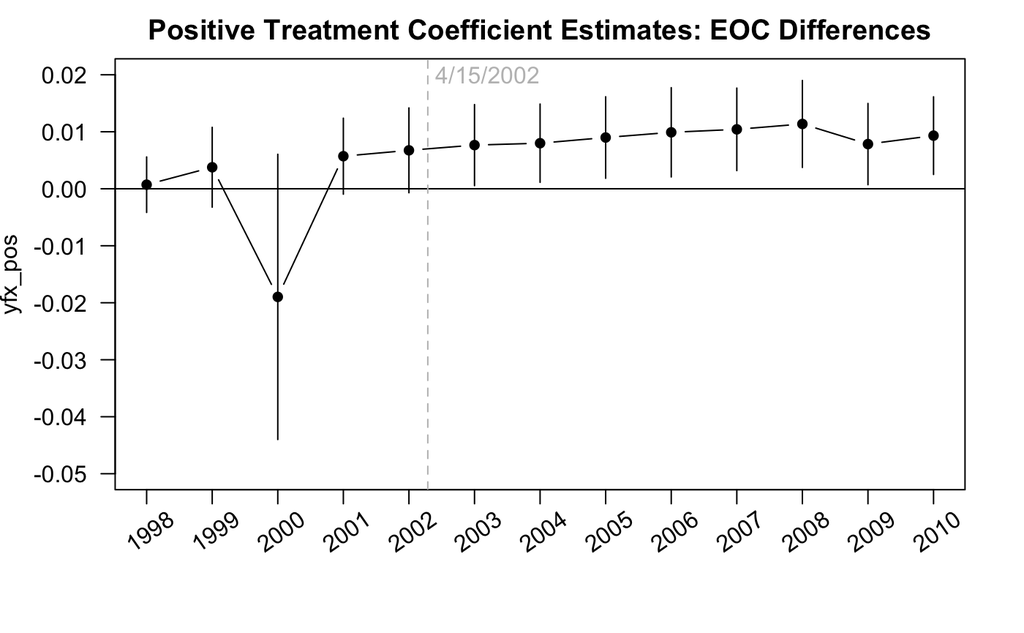

```r
text( x = 2003.2 , y = .02 , labels = "4/15/2002" , col = "gray" )
```

Negative-treatment yearly effects plot with CI bars

```r
# Delineate tick marks for years
xtick = 1998:2010
# Plot of yearly effects with 2 SE (95% CI) bars
plot( y = yfx_neg , x = years , type = "b" , ylim = c(-.03,.01) , pch = 16 , xaxt = "n" ,
      xlab = "" , main = "Negative Treatment Coefficient Estimates: EOC Differences" , las = 1 , mgp = c(3.3,1,0) )
axis(1 , at = 1998:2010 , labels = FALSE)
```

```r
text(x = xtick,  par("usr")[3] - 0.002,
     labels = xtick, srt = 35, pos = 1, xpd = TRUE)
for ( i in 1:length(years) ) {
  ci = yfx_neg[i] + c(-2,2)*sefx_neg[i]
  x = years[i]
  lines( c(x,x) , ci )
}
```

```r
abline( h = 0 )
abline( v = 2002+(105/365) , lty = 2 , col = "gray" )
```

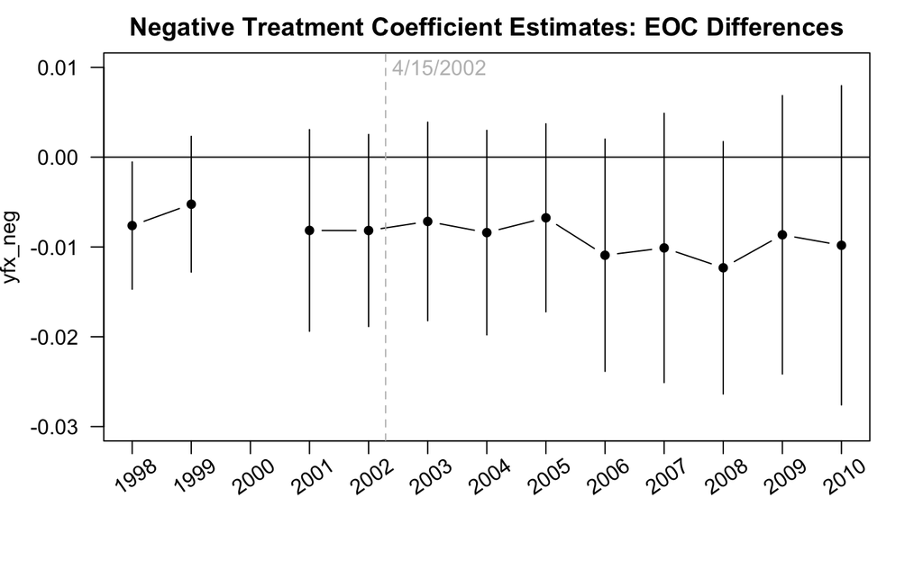

```r
text( x = 2003.2 , y = .01 , labels = "4/15/2002" , col = "gray")
```

## Regressions by EOC quantiles

Quantiles of EOC differences

```r
# Postively treated EOC-difference quantiles
quantile( treated_pos_df$eocptreat[treated_pos_df$eocptreat != 0] ,
          probs = c(.25 , .50 , .75) ,
          na.rm = TRUE )
```

```
  25%   50%   75%
 6.93 16.30 32.30
```

```r
# Negatively treated EOC-difference quantiles
quantile( treated_neg_df$eocntreat[treated_neg_df$eocntreat != 0] ,
          probs = c(.25 , .50 , .75) ,
          na.rm = TRUE )
```

```
   25%    50%    75%
-19.83  -9.97  -3.16
```

Apply same models to treatment quantiles (break treatment into bottom 25%, middle 50%, and top 25% of EOC difference totals)

Positive model results: EOC quantiles

```r
# Positively treated houses quantiles of EOC-difference scores
quant_pos_df = treated_pos_df %>%
  mutate( eocp25 = ifelse(eocdifference != 0 & eocdifference <= 6.93 , 1 , 0) ,
          eocp50 = ifelse(6.93 < eocdifference & eocdifference < 32.3 , 1 , 0) ,
          eocp75 = ifelse(32.3 <= eocdifference , 1 , 0) )
# Bottom 25% of EOC differences
quant_pos_25 = quant_pos_df %>%
  filter( eocp25 == 1 | eocdifference == 0 )
# Middle 50% of EOC differences
quant_pos_50 = quant_pos_df %>%
  filter( eocp50 == 1 | eocdifference == 0 )
# Upper 25% of EOC differences
quant_pos_75 = quant_pos_df %>%
  filter( eocp75 == 1 | eocdifference == 0 )
# Linear model incorporating all three treatment effects
# Bottom 25%
summary(lm_robust(
  lrsp ~ eocdifference + post2002 + eocptreat + acres + beds + baths + half_baths + new + age + agesq + year_fe ,
                data = quant_pos_25 ,
                se_type = "stata" ,
                clusters = quant_pos_25$subdiv) )
```

```
Call:
lm_robust(formula = lrsp ~ eocdifference + post2002 + eocptreat +
    acres + beds + baths + half_baths + new + age + agesq + year_fe,
    data = quant_pos_25, clusters = quant_pos_25$subdiv, se_type = "stata")

Standard error type:  stata

Coefficients:
                Estimate Std. Error  t value  Pr(>|t|)   CI Lower   CI Upper  DF
(Intercept)   10.4424172  9.959e-02 104.8536 0.000e+00  1.025e+01 10.6379860 631
eocdifference -0.0153799  5.250e-03  -2.9297 3.516e-03 -2.569e-02 -0.0050709 631
post2002       0.0176682  1.303e-02   1.3557 1.757e-01 -7.925e-03  0.0432611 631
eocptreat     -0.0036090  4.463e-03  -0.8087 4.190e-01 -1.237e-02  0.0051547 631
acres          0.2901810  3.864e-02   7.5105 2.021e-13  2.143e-01  0.3660533 631
beds           0.2348571  1.444e-02  16.2689 5.892e-50  2.065e-01  0.2632055 631
baths          0.3777919  2.253e-02  16.7685 1.816e-52  3.335e-01  0.4220344 631
half_baths     0.2894505  2.535e-02  11.4169 1.419e-27  2.397e-01  0.3392367 631
new            0.0105786  2.811e-02   0.3763 7.068e-01 -4.463e-02  0.0657854 631
age           -0.0088403  3.072e-03  -2.8774 4.145e-03 -1.487e-02 -0.0028071 631
agesq          0.0001681  5.365e-05   3.1341 1.804e-03  6.278e-05  0.0002735 631
year_fe1998   -0.0354861  2.591e-02  -1.3696 1.713e-01 -8.637e-02  0.0153934 631
year_fe1999    0.0109664  3.117e-02   0.3519 7.250e-01 -5.023e-02  0.0721664 631
year_fe2000    0.0871601  6.614e-02   1.3177 1.881e-01 -4.273e-02  0.2170488 631
year_fe2001   -0.0546808  4.233e-02  -1.2918 1.969e-01 -1.378e-01  0.0284399 631
year_fe2002   -0.0680964  4.436e-02  -1.5350 1.253e-01 -1.552e-01  0.0190177 631
year_fe2003   -0.0593990  4.504e-02  -1.3187 1.877e-01 -1.478e-01  0.0290513 631
year_fe2004   -0.0529857  4.432e-02  -1.1954 2.324e-01 -1.400e-01  0.0340551 631
year_fe2005   -0.0659829  4.486e-02  -1.4707 1.419e-01 -1.541e-01  0.0221169 631
year_fe2006   -0.0430840  4.438e-02  -0.9707 3.321e-01 -1.302e-01  0.0440758 631
year_fe2007   -0.0141608  4.589e-02  -0.3086 7.577e-01 -1.043e-01  0.0759480 631
year_fe2008   -0.0690460  4.672e-02  -1.4778 1.400e-01 -1.608e-01  0.0227066 631
year_fe2009   -0.1331036  4.720e-02  -2.8202 4.949e-03 -2.258e-01 -0.0404239 631
year_fe2010   -0.1875775  5.454e-02  -3.4395 6.213e-04 -2.947e-01 -0.0804820 631

Multiple R-squared:  0.5983 ,   Adjusted R-squared:  0.598
F-statistic: 114.4 on 23 and 631 DF,  p-value: < 2.2e-16
```

```r
# Middle 50%
summary(lm_robust(
  lrsp ~ eocdifference + post2002 + eocptreat + acres + beds + baths + half_baths + new + age + agesq + year_fe ,
                data = quant_pos_50 ,
                se_type = "stata" ,
                clusters = quant_pos_50$subdiv) )
```

```
Call:
lm_robust(formula = lrsp ~ eocdifference + post2002 + eocptreat +
    acres + beds + baths + half_baths + new + age + agesq + year_fe,
    data = quant_pos_50, clusters = quant_pos_50$subdiv, se_type = "stata")

Standard error type:  stata

Coefficients:
                Estimate Std. Error   t value  Pr(>|t|)   CI Lower   CI Upper  DF
(Intercept)   10.4130988  9.878e-02 105.41263 0.000e+00 10.2191073 10.6070903 621
eocdifference -0.0073403  2.316e-03  -3.16878 1.606e-03 -0.0118893 -0.0027913 621
post2002       0.0162359  1.367e-02   1.18760 2.354e-01 -0.0106113  0.0430830 621
eocptreat     -0.0031736  2.031e-03  -1.56267 1.186e-01 -0.0071618  0.0008146 621
acres          0.2935492  3.986e-02   7.36445 5.680e-13  0.2152719  0.3718266 621
beds           0.2363627  1.597e-02  14.80118 1.120e-42  0.2050026  0.2677228 621
baths          0.3781449  2.298e-02  16.45349 9.373e-51  0.3330117  0.4232780 621
half_baths     0.2962971  2.601e-02  11.39221 1.954e-27  0.2452213  0.3473728 621
new            0.0223988  2.971e-02   0.75400 4.511e-01 -0.0359390  0.0807365 621
age           -0.0098746  2.763e-03  -3.57429 3.784e-04 -0.0153000 -0.0044493 621
agesq          0.0001912  4.089e-05   4.67669 3.579e-06  0.0001109  0.0002715 621
year_fe1998   -0.0120441  2.400e-02  -0.50193 6.159e-01 -0.0591661  0.0350779 621
year_fe1999    0.0239959  3.353e-02   0.71568 4.745e-01 -0.0418479  0.0898398 621
year_fe2000    0.1536027  6.442e-02   2.38423 1.741e-02  0.0270863  0.2801192 621
year_fe2001   -0.0342690  4.593e-02  -0.74607 4.559e-01 -0.1244716  0.0559335 621
year_fe2002   -0.0394429  4.806e-02  -0.82062 4.122e-01 -0.1338322  0.0549465 621
year_fe2003   -0.0357010  4.906e-02  -0.72774 4.670e-01 -0.1320397  0.0606378 621
year_fe2004   -0.0279404  4.810e-02  -0.58083 5.616e-01 -0.1224077  0.0665270 621
year_fe2005   -0.0429408  4.855e-02  -0.88441 3.768e-01 -0.1382890  0.0524073 621
year_fe2006   -0.0286073  4.826e-02  -0.59281 5.535e-01 -0.1233734  0.0661589 621
year_fe2007    0.0042151  4.949e-02   0.08517 9.322e-01 -0.0929778  0.1014081 621
year_fe2008   -0.0486693  5.030e-02  -0.96758 3.336e-01 -0.1474484  0.0501097 621
year_fe2009   -0.1195742  5.077e-02  -2.35514 1.883e-02 -0.2192789 -0.0198694 621
year_fe2010   -0.1618434  5.741e-02  -2.81884 4.973e-03 -0.2745941 -0.0490926 621

Multiple R-squared:  0.6028 ,   Adjusted R-squared:  0.6025
F-statistic: 96.59 on 23 and 621 DF,  p-value: < 2.2e-16
```

```r
# Upper 75%
summary(lm_robust(
  lrsp ~ eocdifference + post2002 + eocptreat + acres + beds + baths + half_baths + new + age + agesq + year_fe ,
                data = quant_pos_75 ,
                se_type = "stata" ,
                clusters = quant_pos_75$subdiv) )
```

```
Call:
lm_robust(formula = lrsp ~ eocdifference + post2002 + eocptreat +
    acres + beds + baths + half_baths + new + age + agesq + year_fe,
    data = quant_pos_75, clusters = quant_pos_75$subdiv, se_type = "stata")

Standard error type:  stata

Coefficients:
               Estimate Std. Error  t value  Pr(>|t|)   CI Lower  CI Upper  DF
(Intercept)   10.451550  1.012e-01 103.2322 0.000e+00  1.025e+01 10.650398 580
eocdifference  0.011266  3.861e-03   2.9176 3.664e-03  3.682e-03  0.018849 580
post2002       0.011038  1.394e-02   0.7919 4.288e-01 -1.634e-02  0.038414 580
eocptreat      0.004480  9.670e-04   4.6331 4.452e-06  2.581e-03  0.006380 580
acres          0.296663  4.103e-02   7.2312 1.520e-12  2.161e-01  0.377240 580
beds           0.231234  1.625e-02  14.2295 1.255e-39  1.993e-01  0.263151 580
baths          0.374675  2.183e-02  17.1656 1.037e-53  3.318e-01  0.417545 580
half_baths     0.290582  2.636e-02  11.0236 8.705e-26  2.388e-01  0.342354 580
new            0.012302  3.235e-02   0.3803 7.039e-01 -5.123e-02  0.075837 580
age           -0.009584  2.673e-03  -3.5857 3.645e-04 -1.483e-02 -0.004334 580
agesq          0.000172  3.821e-05   4.5014 8.161e-06  9.694e-05  0.000247 580
year_fe1998   -0.018962  2.511e-02  -0.7551 4.505e-01 -6.828e-02  0.030360 580
year_fe1999    0.025753  3.433e-02   0.7502 4.534e-01 -4.167e-02  0.093175 580
year_fe2000    0.161922  6.639e-02   2.4389 1.503e-02  3.153e-02  0.292317 580
year_fe2001   -0.032304  4.811e-02  -0.6714 5.022e-01 -1.268e-01  0.062191 580
year_fe2002   -0.046076  4.998e-02  -0.9219 3.570e-01 -1.442e-01  0.052089 580
year_fe2003   -0.036853  5.184e-02  -0.7108 4.775e-01 -1.387e-01  0.064972 580
year_fe2004   -0.028693  5.081e-02  -0.5647 5.725e-01 -1.285e-01  0.071102 580
year_fe2005   -0.041316  5.188e-02  -0.7964 4.261e-01 -1.432e-01  0.060580 580
year_fe2006   -0.014803  5.214e-02  -0.2839 7.766e-01 -1.172e-01  0.087604 580
year_fe2007    0.023737  5.278e-02   0.4497 6.531e-01 -7.993e-02  0.127401 580
year_fe2008   -0.029855  5.350e-02  -0.5580 5.771e-01 -1.349e-01  0.075229 580
year_fe2009   -0.109990  5.381e-02  -2.0440 4.141e-02 -2.157e-01 -0.004299 580
year_fe2010   -0.164528  5.981e-02  -2.7507 6.133e-03 -2.820e-01 -0.047051 580

Multiple R-squared:  0.6395 ,   Adjusted R-squared:  0.6393
F-statistic: 183.6 on 23 and 580 DF,  p-value: < 2.2e-16
```

Negative model results: EOC quantiles

```r
# Positively treated houses quantiles of EOC-difference scores
quant_neg_df = treated_neg_df %>%
  mutate( eocn25 = ifelse(eocdifference != 0 & eocdifference <= -19.83 , 1 , 0) ,
          eocn50 = ifelse(-3.16 > eocdifference & eocdifference > -19.83 , 1 , 0) ,
          eocn75 = ifelse( -3.16 <= eocdifference , 1 , 0) )
# Bottom 25% of EOC differences
quant_neg_25 = quant_neg_df %>%
  filter( eocn25 == 1 | eocdifference == 0 )
# Middle 50% of EOC differences
quant_neg_50 = quant_neg_df %>%
  filter( eocn50 == 1 | eocdifference == 0 )
# Upper 25% of EOC differences
quant_neg_75 = quant_neg_df %>%
  filter( eocn75 == 1 | eocdifference == 0 )
# Linear model incorporating all three treatment effects
# Bottom 25%
summary(lm_robust(
  lrsp ~ eocdifference + post2002 + eocntreat + acres + beds + baths + half_baths + new + age + agesq + year_fe ,
                data = quant_neg_25 ,
                se_type = "stata" ,
                clusters = quant_neg_25$subdiv) )
```

```
Call:
lm_robust(formula = lrsp ~ eocdifference + post2002 + eocntreat +
    acres + beds + baths + half_baths + new + age + agesq + year_fe,
    data = quant_neg_25, clusters = quant_neg_25$subdiv, se_type = "stata")

Standard error type:  stata

Coefficients:
                Estimate Std. Error  t value  Pr(>|t|)   CI Lower   CI Upper  DF
(Intercept)   10.4085765  1.024e-01 101.6333 0.000e+00  1.021e+01 10.6097129 593
eocdifference  0.0026371  4.970e-03   0.5306 5.959e-01 -7.124e-03  0.0123978 593
post2002       0.0086571  1.390e-02   0.6228 5.336e-01 -1.864e-02  0.0359549 593
eocntreat     -0.0041005  1.597e-03  -2.5678 1.048e-02 -7.237e-03 -0.0009642 593
acres          0.2999641  4.252e-02   7.0544 4.851e-12  2.165e-01  0.3834755 593
beds           0.2344213  1.681e-02  13.9484 1.904e-38  2.014e-01  0.2674284 593
baths          0.3878751  2.304e-02  16.8338 2.894e-52  3.426e-01  0.4331278 593
half_baths     0.2852429  2.538e-02  11.2371 1.075e-26  2.354e-01  0.3350964 593
new            0.0073377  3.205e-02   0.2290 8.190e-01 -5.560e-02  0.0702801 593
age           -0.0095706  2.906e-03  -3.2929 1.051e-03 -1.528e-02 -0.0038624 593
agesq          0.0001787  4.517e-05   3.9567 8.520e-05  9.001e-05  0.0002674 593
year_fe1998   -0.0134474  2.552e-02  -0.5269 5.984e-01 -6.357e-02  0.0366718 593
year_fe1999    0.0274344  3.467e-02   0.7914 4.290e-01 -4.065e-02  0.0955168 593
year_fe2000    0.1606844  6.607e-02   2.4321 1.531e-02  3.093e-02  0.2904415 593
year_fe2001   -0.0311925  4.788e-02  -0.6515 5.150e-01 -1.252e-01  0.0628434 593
year_fe2002   -0.0420741  4.995e-02  -0.8424 3.999e-01 -1.402e-01  0.0560201 593
year_fe2003   -0.0330263  5.207e-02  -0.6343 5.261e-01 -1.353e-01  0.0692281 593
year_fe2004   -0.0243573  5.079e-02  -0.4796 6.317e-01 -1.241e-01  0.0753952 593
year_fe2005   -0.0403889  5.142e-02  -0.7855 4.325e-01 -1.414e-01  0.0605959 593
year_fe2006   -0.0138475  5.144e-02  -0.2692 7.879e-01 -1.149e-01  0.0871848 593
year_fe2007    0.0183511  5.256e-02   0.3492 7.271e-01 -8.487e-02  0.1215749 593
year_fe2008   -0.0320532  5.319e-02  -0.6026 5.470e-01 -1.365e-01  0.0724135 593
year_fe2009   -0.1024565  5.350e-02  -1.9150 5.598e-02 -2.075e-01  0.0026228 593
year_fe2010   -0.1455582  6.098e-02  -2.3868 1.731e-02 -2.653e-01 -0.0257865 593

Multiple R-squared:  0.5923 ,   Adjusted R-squared:  0.592
F-statistic: 105.5 on 23 and 593 DF,  p-value: < 2.2e-16
```

```r
# Middle 50%
summary(lm_robust(
  lrsp ~ eocdifference + post2002 + eocntreat + acres + beds + baths + half_baths + new + age + agesq + year_fe ,
                data = quant_neg_50 ,
                se_type = "stata" ,
                clusters = quant_neg_50$subdiv) )
```

```
Call:
lm_robust(formula = lrsp ~ eocdifference + post2002 + eocntreat +
    acres + beds + baths + half_baths + new + age + agesq + year_fe,
    data = quant_neg_50, clusters = quant_neg_50$subdiv, se_type = "stata")

Standard error type:  stata

Coefficients:
                Estimate Std. Error   t value  Pr(>|t|)  CI Lower   CI Upper  DF
(Intercept)   10.4426414   0.101488 102.89526 0.000e+00 10.243340 10.6419428 621
eocdifference -0.0005598   0.004757  -0.11767 9.064e-01 -0.009902  0.0087821 621
post2002       0.0182651   0.013774   1.32606 1.853e-01 -0.008784  0.0453144 621
eocntreat      0.0088198   0.004736   1.86223 6.304e-02 -0.000481  0.0181206 621
acres          0.3158977   0.042885   7.36618 5.612e-13  0.231681  0.4001147 621
beds           0.2355163   0.016320  14.43097 6.395e-41  0.203467  0.2675657 621
baths          0.3859447   0.022744  16.96906 2.409e-53  0.341280  0.4306092 621
half_baths     0.2826683   0.024749  11.42151 1.479e-27  0.234067  0.3312697 621
new           -0.0013568   0.030691  -0.04421 9.648e-01 -0.061627  0.0589135 621
age           -0.0116794   0.003101  -3.76599 1.817e-04 -0.017770 -0.0055891 621
agesq          0.0001981   0.000052   3.80992 1.528e-04  0.000096  0.0003002 621
year_fe1998   -0.0101748   0.024032  -0.42339 6.722e-01 -0.057368  0.0370183 621
year_fe1999    0.0223898   0.032835   0.68188 4.956e-01 -0.042092  0.0868713 621
year_fe2000    0.1563607   0.065142   2.40029 1.668e-02  0.028435  0.2842868 621
year_fe2001   -0.0383034   0.044782  -0.85532 3.927e-01 -0.126247  0.0496399 621
year_fe2002   -0.0489996   0.046946  -1.04374 2.970e-01 -0.141192  0.0431928 621
year_fe2003   -0.0432007   0.049008  -0.88150 3.784e-01 -0.139443  0.0530415 621
year_fe2004   -0.0356504   0.047905  -0.74419 4.570e-01 -0.129726  0.0584247 621
year_fe2005   -0.0484553   0.048567  -0.99771 3.188e-01 -0.143830  0.0469196 621
year_fe2006   -0.0397770   0.048326  -0.82310 4.108e-01 -0.134679  0.0551254 621
year_fe2007   -0.0094641   0.049464  -0.19133 8.483e-01 -0.106602  0.0876735 621
year_fe2008   -0.0644798   0.049959  -1.29066 1.973e-01 -0.162589  0.0336292 621
year_fe2009   -0.1395689   0.051625  -2.70354 7.048e-03 -0.240949 -0.0381890 621
year_fe2010   -0.1796526   0.058889  -3.05069 2.381e-03 -0.295299 -0.0640064 621

Multiple R-squared:  0.5983 ,   Adjusted R-squared:  0.598
F-statistic: 99.45 on 23 and 621 DF,  p-value: < 2.2e-16
```

```r
# Upper 75%
summary(lm_robust(
  lrsp ~ eocdifference + post2002 + eocntreat + acres + beds + baths + half_baths + new + age + agesq + year_fe ,
                data = quant_neg_75 ,
                se_type = "stata" ,
                clusters = quant_neg_75$subdiv) )
```

```
Call:
lm_robust(formula = lrsp ~ eocdifference + post2002 + eocntreat +
    acres + beds + baths + half_baths + new + age + agesq + year_fe,
    data = quant_neg_75, clusters = quant_neg_75$subdiv, se_type = "stata")

Standard error type:  stata

Coefficients:
                Estimate Std. Error  t value  Pr(>|t|)   CI Lower   CI Upper  DF
(Intercept)   10.4239364  1.025e-01 101.6769 0.000e+00 10.2225875 10.6252853 590
eocdifference  0.0644957  1.478e-02   4.3648 1.502e-05  0.0354753  0.0935162 590
post2002       0.0156752  1.378e-02   1.1377 2.557e-01 -0.0113839  0.0427344 590
eocntreat      0.0133876  9.949e-03   1.3456 1.789e-01 -0.0061522  0.0329273 590
acres          0.3122913  4.368e-02   7.1493 2.589e-12  0.2265016  0.3980811 590
beds           0.2351253  1.670e-02  14.0798 5.020e-39  0.2023278  0.2679229 590
baths          0.3822081  2.311e-02  16.5380 9.283e-51  0.3368184  0.4275979 590
half_baths     0.2857867  2.533e-02  11.2839 7.134e-27  0.2360447  0.3355286 590
new            0.0064060  3.165e-02   0.2024 8.397e-01 -0.0557512  0.0685632 590
age           -0.0096539  3.098e-03  -3.1165 1.919e-03 -0.0157376 -0.0035701 590
agesq          0.0001781  5.278e-05   3.3735 7.908e-04  0.0000744  0.0002817 590
year_fe1998   -0.0176277  2.543e-02  -0.6931 4.885e-01 -0.0675760  0.0323205 590
year_fe1999    0.0221802  3.470e-02   0.6391 5.230e-01 -0.0459780  0.0903385 590
year_fe2000    0.1558080  6.622e-02   2.3531 1.895e-02  0.0257618  0.2858541 590
year_fe2001   -0.0379727  4.791e-02  -0.7925 4.284e-01 -0.1320723  0.0561268 590
year_fe2002   -0.0506696  4.998e-02  -1.0137 3.111e-01 -0.1488352  0.0474960 590
year_fe2003   -0.0414248  5.208e-02  -0.7954 4.267e-01 -0.1437092  0.0608596 590
year_fe2004   -0.0341753  5.086e-02  -0.6719 5.019e-01 -0.1340692  0.0657187 590
year_fe2005   -0.0486654  5.141e-02  -0.9467 3.442e-01 -0.1496257  0.0522949 590
year_fe2006   -0.0289031  5.120e-02  -0.5645 5.726e-01 -0.1294659  0.0716598 590
year_fe2007    0.0070128  5.219e-02   0.1344 8.931e-01 -0.0954817  0.1095072 590
year_fe2008   -0.0448138  5.244e-02  -0.8546 3.931e-01 -0.1478053  0.0581778 590
year_fe2009   -0.1144514  5.326e-02  -2.1488 3.206e-02 -0.2190598 -0.0098431 590
year_fe2010   -0.1597468  5.966e-02  -2.6774 7.625e-03 -0.2769269 -0.0425667 590

Multiple R-squared:  0.6026 ,   Adjusted R-squared:  0.6023
F-statistic: 105.7 on 23 and 590 DF,  p-value: < 2.2e-16
```

## Quantile regressions across house-price distribution

Positively treated houses across 10% quantiles of house-price distribution

```r
quant_pos = rq(
  lrsp ~ rezonepos + post2002 + treatpos + acres + beds + baths + half_baths + new + age + agesq + year_fe ,
  data = treated_pos_df ,
  tau = seq(.1,.9,by=.1) )
```

```
Solution may be nonuniqueSolution may be nonunique
```

```r
quant_pos
```

```
Call:
rq(formula = lrsp ~ rezonepos + post2002 + treatpos + acres +
    beds + baths + half_baths + new + age + agesq + year_fe,
    tau = seq(0.1, 0.9, by = 0.1), data = treated_pos_df)

Coefficients:
                 tau= 0.1      tau= 0.2      tau= 0.3     tau= 0.4     tau= 0.5      tau= 0.6      tau= 0.7
(Intercept) 10.3729521291 10.2601535441 10.2131418249 10.195021044 10.177587332 10.1902930290 10.2469987581
rezonepos   -0.0180715511 -0.0053592836 -0.0045468729 -0.010570122 -0.005703707 -0.0151743369 -0.0373513532
post2002    -0.0277539431  0.0078920378  0.0198560440  0.009580308  0.018220255  0.0280898034  0.0347219916
treatpos     0.0372172474  0.0075021593  0.0005573724 -0.002507616 -0.012653528 -0.0125010716 -0.0089842042
acres        0.2210267800  0.2515245925  0.2799979576  0.307477552  0.337791241  0.3465410598  0.3845109088
beds         0.2252008614  0.2358798800  0.2449756631  0.248704372  0.250123822  0.2571498667  0.2589711404
baths        0.3228484980  0.3462594597  0.3646831498  0.381321819  0.397183422  0.4188846248  0.4380514575
half_baths   0.2194597405  0.3065237390  0.3463876852  0.347976887  0.375245910  0.3734649151  0.3657934789
new         -0.0318309844 -0.0253516456 -0.0177465192 -0.009308807  0.011329649  0.0237580638  0.0326127899
age         -0.0136438536 -0.0125911047 -0.0120611950 -0.010803887 -0.010334223 -0.0095588757 -0.0097248458
agesq        0.0002045107  0.0002374176  0.0002561136  0.000259704  0.000268241  0.0002692923  0.0002813286
year_fe1998  0.0066602989  0.0041565633 -0.0171436923 -0.025051677 -0.041660807 -0.0801983462 -0.1097488005
year_fe1999  0.0143162858  0.0217967243 -0.0014377252  0.019259929  0.026819247 -0.0108871022 -0.0092765302
year_fe2000  0.0737404549  0.1363819416  0.0991631303  0.107500101  0.065011047  0.0294488971  0.0846060116
year_fe2001  0.0063208482 -0.0104119899 -0.0422925043 -0.038086489 -0.041842430 -0.0689771601 -0.0918385768
year_fe2002 -0.0098202042 -0.0319859188 -0.0564980145 -0.040246045 -0.050858595 -0.0741772751 -0.1090701871
year_fe2003 -0.0232051852 -0.0421363355 -0.0665982147 -0.048791419 -0.045280136 -0.0695679592 -0.0999347383
year_fe2004 -0.0175180413 -0.0471590127 -0.0677541075 -0.051669195 -0.056300394 -0.0826911164 -0.0973155062
year_fe2005 -0.0483319692 -0.0719549184 -0.0934365552 -0.068307640 -0.070594660 -0.0891092215 -0.1095980500
year_fe2006 -0.0512313537 -0.0715515995 -0.0803723043 -0.044585446 -0.042262285 -0.0572533043 -0.0698672771
year_fe2007 -0.0514489141 -0.0554206447 -0.0534799363 -0.017466643 -0.010083023 -0.0208404625 -0.0257502325
year_fe2008 -0.1310507116 -0.1172951491 -0.1075399871 -0.070223866 -0.051344679 -0.0571078226 -0.0632172752
year_fe2009 -0.2198132024 -0.1874487893 -0.1643184848 -0.120342086 -0.111930770 -0.1288355551 -0.1331266474
year_fe2010 -0.2357290656 -0.1993582725 -0.2312272884 -0.207383315 -0.174841130 -0.1816260680 -0.1730765217
                 tau= 0.8      tau= 0.9
(Intercept) 10.2602703029 10.3526048820
rezonepos   -0.0666673432 -0.1080807044
post2002     0.0163716560  0.0089757353
treatpos     0.0012113178  0.0655506073
acres        0.4173146524  0.4281377361
beds         0.2536680589  0.2441707005
baths        0.4645992048  0.4811904484
half_baths   0.3738146464  0.3898707587
new          0.0498566370  0.0731056457
age         -0.0090848327 -0.0094378966
agesq        0.0002834219  0.0002945774
year_fe1998 -0.0731824531 -0.0108416382
year_fe1999  0.0141173782  0.0289076637
year_fe2000  0.0520189782  0.0339050772
year_fe2001 -0.0690411822 -0.0185230495
year_fe2002 -0.0734137935 -0.0443716382
year_fe2003 -0.0579641903  0.0021872477
year_fe2004 -0.0527526630  0.0058986668
year_fe2005 -0.0507573530  0.0298102256
year_fe2006 -0.0088313175  0.0665462020
year_fe2007  0.0297162223  0.1050776945
year_fe2008  0.0224911751  0.0876172782
year_fe2009 -0.0753820900 -0.0150426389
year_fe2010 -0.1072176714 -0.0120932916

Degrees of freedom: 38863 total; 38839 residual
```

Boostrap neighborhood-clustered standard errors across quantile regressions

```r
# # Specify neighborhood clusters
# neigh_clust = as.factor(treated_pos_df$subdiv[-1])
#
# # Specify quantiles
# quants = seq(0.1 , 0.9 , by = 0.1)
#
# # Calculate CI bands and store in empty array
# qr_array = array(NA , c(nrow = length(quants) , ncol = 2))
#
# for ( i in 1:length(quants) ) {
#   qr_b = boot.rq(x = quant_pos$x , y = quant_pos$y , tau = quants[i] , R = 500 , cluster = neigh_clust)
#   qr_array[i,] = quantile(qr_b$B[,4] , probs = c(.025,.975) )
# }
```

```r
# # Plot results and 95% clustered, bootstrap CIs
# plot(quant_pos$coefficients[4,] , ylim = range(qr_array) , pch = 16 , xaxt = "n" ,
#      ylab = "Coefficient estimate" , xlab = "Quantile" , main = "Positively Treated House Price Effects: Quantile Regressions")
# axis(1 , at = seq(1,9,by=1) , labels = seq(.1,.9,by=.1))
# lines(qr_array[,1] , lty = 2)
# lines(qr_array[,2] , lty = 2)
# abline(h = 0)
```

Negatively treated houses across 10% quantiles of house price distribution

```r
quant_neg = rq(
  lrsp ~ rezoneneg + post2002 + treatneg + acres + beds + baths + half_baths + new + age + agesq + year_fe ,
  data = treated_neg_df ,
  tau = seq(.1,.9,by=.1) )
```

```
Solution may be nonuniqueSolution may be nonuniqueSolution may be nonuniqueSolution may be nonuniqueSolution may be nonuniqueSolution may be nonuniqueSolution may be nonuniqueSolution may be nonuniqueSolution may be nonunique
```

```r
quant_neg
```

```
Call:
rq(formula = lrsp ~ rezoneneg + post2002 + treatneg + acres +
    beds + baths + half_baths + new + age + agesq + year_fe,
    tau = seq(0.1, 0.9, by = 0.1), data = treated_neg_df)

Coefficients:
                 tau= 0.1      tau= 0.2      tau= 0.3    tau= 0.4      tau= 0.5      tau= 0.6      tau= 0.7
(Intercept)  1.045301e+01 10.4008966558 10.3670865385 10.33771739 10.3508685070 10.3630634010 10.4332860514
rezoneneg   -7.531156e-02 -0.0727435600 -0.0528913468 -0.03270063 -0.0262017316 -0.0330884150 -0.0443236554
post2002    -7.111392e-03  0.0219389342  0.0210218753  0.02130743  0.0181422817  0.0318126785  0.0426167782
treatneg     3.662886e-05 -0.0046806663 -0.0296835969 -0.04456116 -0.0584571173 -0.0450544692 -0.0391479849
acres        2.866263e-01  0.3371760623  0.3595131883  0.37670318  0.4058296708  0.4163745593  0.4410896503
beds         2.305205e-01  0.2413094037  0.2506689777  0.25215024  0.2530970012  0.2634462580  0.2628647849
baths        3.134285e-01  0.3311619032  0.3453421590  0.36387184  0.3771603517  0.3918641049  0.4063993942
half_baths   1.608935e-01  0.2377783269  0.2810169938  0.30486962  0.3076811709  0.3124932484  0.3086295818
new         -5.553869e-02 -0.0640538076 -0.0670274065 -0.06611929 -0.0420308271 -0.0213955695  0.0067490082
age         -1.279488e-02 -0.0146564128 -0.0153359411 -0.01575055 -0.0166220451 -0.0167478217 -0.0164463642
agesq        1.239493e-04  0.0001943739  0.0002309923  0.00025594  0.0002874377  0.0003027955  0.0003095548
year_fe1998 -4.160703e-04  0.0003845516 -0.0121977957  0.00776593  0.0133788083 -0.0180672503 -0.0612851685
year_fe1999  4.408942e-03 -0.0043600543 -0.0054091049  0.05396963  0.0766346637  0.0504446228  0.0339282779
year_fe2000  2.420288e-01  0.2152899488  0.1745940798  0.21110124  0.2438299930  0.2903358371  0.1910357126
year_fe2001  7.485280e-03 -0.0244469100 -0.0480331473 -0.02911028 -0.0174003339 -0.0405375763 -0.0663896235
year_fe2002 -1.986053e-02 -0.0528937281 -0.0551367333 -0.04046998 -0.0191091643 -0.0494085739 -0.0817145570
year_fe2003 -4.523081e-02 -0.0675562902 -0.0655440232 -0.04259357 -0.0088879486 -0.0375924734 -0.0725276736
year_fe2004 -3.749767e-02 -0.0670819534 -0.0684305765 -0.04391301 -0.0173359698 -0.0388250411 -0.0684727341
year_fe2005 -7.546249e-02 -0.0987867933 -0.0956202521 -0.07104421 -0.0372037898 -0.0538918084 -0.0793244540
year_fe2006 -8.290988e-02 -0.1106152146 -0.0969484736 -0.06032083 -0.0209515120 -0.0310683786 -0.0485595300
year_fe2007 -9.560120e-02 -0.1005268559 -0.0781988813 -0.03485245  0.0054629496 -0.0069674133 -0.0059857390
year_fe2008 -1.754597e-01 -0.1542786648 -0.1272574333 -0.07275672 -0.0232569056 -0.0322188078 -0.0310841219
year_fe2009 -2.856976e-01 -0.2298174568 -0.1886463815 -0.12631022 -0.0834359865 -0.0873591903 -0.1185991150
year_fe2010 -3.382902e-01 -0.2693195780 -0.2752216977 -0.20719476 -0.1520200176 -0.1232139562 -0.1247967925
                 tau= 0.8      tau= 0.9
(Intercept) 10.5286255576 10.6976769104
rezoneneg   -0.0617803404 -0.0795469641
post2002     0.0360298973  0.0463778389
treatneg    -0.0248612347  0.0042143819
acres        0.4767544973  0.4834610631
beds         0.2556615085  0.2247550121
baths        0.4227375684  0.4338091846
half_baths   0.2988721856  0.3147414196
new          0.0330110767  0.0599151781
age         -0.0165809378 -0.0167982325
agesq        0.0003174767  0.0003204963
year_fe1998 -0.0498989604  0.0212883291
year_fe1999  0.0337799704  0.0441415206
year_fe2000  0.1062353535  0.1490407417
year_fe2001 -0.0725720207 -0.0123558754
year_fe2002 -0.0797181473 -0.0447528983
year_fe2003 -0.0586237362 -0.0133146922
year_fe2004 -0.0680364439  0.0003142484
year_fe2005 -0.0575459795  0.0163998397
year_fe2006 -0.0226547628  0.0548817423
year_fe2007  0.0221944555  0.1003977978
year_fe2008  0.0118094107  0.0764141523
year_fe2009 -0.0905233566 -0.0062280224
year_fe2010 -0.0969257673 -0.0234319658

Degrees of freedom: 33101 total; 33077 residual
```

Boostrap neighborhood-clustered standard errors across quantile regressions

```r
# # Specify neighborhood clusters
# neigh_clust = as.factor(treated_neg_df$subdiv[-1])
#
# # Specify quantiles
# quants = seq(0.1 , 0.9 , by = 0.1)
#
# # Calculate CI bands and store in empty array
# qr_array = array(NA , c(nrow = length(quants) , ncol = 2))
#
# for ( i in 1:length(quants) ) {
#   qr_b = boot.rq(x = quant_neg$x , y = quant_neg$y , tau = quants[i] , R = 500 , cluster = neigh_clust)
#   qr_array[i,] = quantile(qr_b$B[,4] , probs = c(.025,.975) )
# }
```

```r
# plot(quant_neg$coefficients[4,] , ylim = range(qr_array) , pch = 16 , xaxt = "n" ,
#      ylab = "Coefficient estimate" , xlab = "Quantile" , main = "Negatively Treated House Price Effects: Quantile Regressions")
# axis(1 , at = seq(1,9,by=1) , labels = seq(.1,.9,by=.1))
# lines(qr_array[,1] , lty = 2)
# lines(qr_array[,2] , lty = 2)
# abline(h = 0)
```